# Longitudinal analysis

12 abril, 2020

# 1 Longitudinal analysis

```r
library(sjPlot)
library(dplyr)
library(lavaan)
library(stargazer)
library(corrplot)
library(psych)
library(knitr)
library(kableExtra)
```

```r
load(file = "input/data/proc/datawide_123.RData")
```

```r
g01<- wide02 %>% filter(grupo==1) %>% select(starts_with("perc_"),starts_with("pref_")) # Fixed by perception/preference
g02<- wide02 %>% filter(grupo==2) %>% select(starts_with("perc_"),starts_with("pref_")) # Fixed by topic (i.e: effort)
g03<- wide02 %>% filter(grupo==3) %>% select(starts_with("perc_"),starts_with("pref_")) # Randomized
```

### 1.0.1 Grupo Versión 01

```r
stargazer(g01,type = "html", median = T,digits = 2)
```

| Statistic | N | Mean | St. Dev. | Min | Pctl(25) | Median | Pctl(75) | Max |
| --- | --- | --- | --- | --- | --- | --- | --- | --- |
| perc_effort_w1 | 486 | 3.22 | 1.35 | 1 | 2 | 3 | 4 | 5 |
| perc_talent_w1 | 486 | 3.02 | 1.11 | 1 | 2 | 3 | 4 | 5 |
| perc_wpart_w1 | 486 | 3.61 | 1.36 | 1 | 3 | 4 | 5 | 5 |
| perc_netw_w1 | 486 | 3.76 | 1.23 | 1 | 3 | 4 | 5 | 5 |
| perc_effort_w2 | 486 | 3.33 | 1.23 | 1 | 2 | 3.5 | 4 | 5 |
| perc_talent_w2 | 486 | 3.13 | 1.09 | 1 | 2 | 3 | 4 | 5 |
| perc_wpart_w2 | 486 | 3.59 | 1.30 | 1 | 3 | 4 | 5 | 5 |
| perc_netw_w2 | 486 | 3.56 | 1.26 | 1 | 3 | 4 | 4 | 5 |
| perc_effort_w3 | 486 | 3.47 | 1.16 | 1 | 3 | 4 | 4 | 5 |
| perc_talent_w3 | 486 | 3.18 | 1.01 | 1 | 3 | 3 | 4 | 5 |
| perc_wpart_w3 | 486 | 3.38 | 1.30 | 1 | 3 | 4 | 4 | 5 |
| perc_netw_w3 | 486 | 3.52 | 1.20 | 1 | 3 | 4 | 4 | 5 |
| pref_effort_w1 | 486 | 3.91 | 1.24 | 1 | 3 | 4 | 5 | 5 |
| pref_talent_w1 | 486 | 3.33 | 1.15 | 1 | 3 | 3 | 4 | 5 |
| pref_wpart_w1 | 486 | 2.54 | 1.12 | 1 | 2 | 3 | 3 | 5 |
| pref_netw_w1 | 486 | 2.30 | 1.06 | 1 | 1 | 2 | 3 | 5 |
| pref_effort_w2 | 486 | 3.92 | 1.13 | 1 | 3 | 4 | 5 | 5 |
| pref_talent_w2 | 486 | 3.30 | 1.10 | 1 | 3 | 3 | 4 | 5 |
| pref_wpart_w2 | 486 | 2.60 | 1.14 | 1 | 2 | 3 | 3 | 5 |
| pref_netw_w2 | 486 | 2.29 | 1.09 | 1 | 1 | 2 | 3 | 5 |
| pref_effort_w3 | 486 | 4.03 | 1.11 | 1 | 4 | 4 | 5 | 5 |
| pref_talent_w3 | 486 | 3.49 | 1.01 | 1 | 3 | 4 | 4 | 5 |
| pref_wpart_w3 | 486 | 2.51 | 1.16 | 1 | 2 | 3 | 3 | 5 |
| pref_netw_w3 | 486 | 2.35 | 1.08 | 1 | 2 | 2 | 3 | 5 |

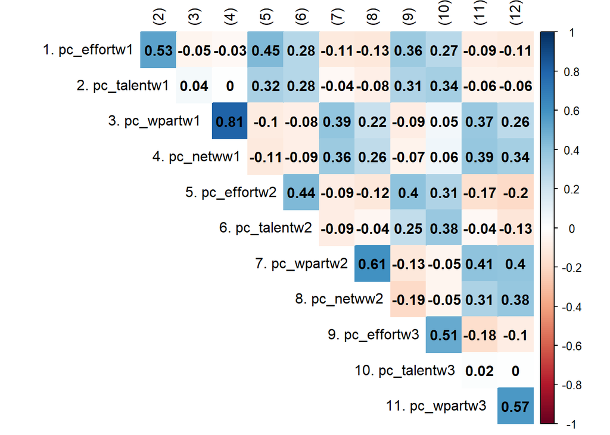

Percepción

```r
corwide01a<- polychoric(x = select(g01 ,starts_with(match = "perc_")),na.rm = T)
rownames(corwide01a$rho) <-c("1. pc_effortw1","2. pc_talentw1","3. pc_wpartw1 ","4. pc_netww1","5. pc_effortw2","6. pc_talentw2","7. pc_wpartw2","8. pc_netww2","9. pc_effortw3","10. pc_talentw3","11. pc_wpartw3 ","12. pc_netww3")
colnames(corwide01a$rho) <-c("(1)", "(2)","(3)","(4)","(5)","(6)","(7)", "(8)","(9)","(10)","(11)","(12)")
corrplot(corwide01a$rho,method = "color", type = "upper", tl.col = "black", addCoef.col = "black",diag = FALSE)
```

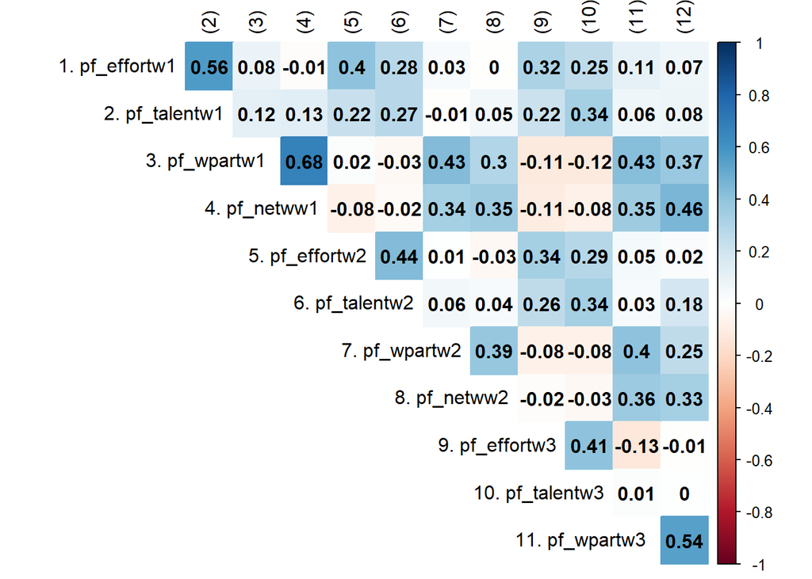

Preferencia

```r
corwide01b<- polychoric(x = select(g01 ,starts_with(match = "pref_")),na.rm = T)
rownames(corwide01b$rho) <-c("1. pf_effortw1","2. pf_talentw1","3. pf_wpartw1 ","4. pf_netww1","5. pf_effortw2","6. pf_talentw2","7. pf_wpartw2","8. pf_netww2","9. pf_effortw3","10. pf_talentw3","11. pf_wpartw3 ","12. pf_netww3")
colnames(corwide01b$rho) <-c("(1)", "(2)","(3)","(4)","(5)","(6)","(7)", "(8)","(9)","(10)","(11)","(12)")
corrplot(corwide01b$rho,method = "color", type = "upper", tl.col = "black", addCoef.col = "black",diag = FALSE)
```

### 1.0.2 Grupo Versión 02

```r
stargazer(g02,type = "html", median = T,digits = 2)
```

| Statistic | N | Mean | St. Dev. | Min | Pctl(25) | Median | Pctl(75) | Max |
| --- | --- | --- | --- | --- | --- | --- | --- | --- |
| perc_effort_w1 | 471 | 3.10 | 1.42 | 1 | 2 | 3 | 4 | 5 |
| perc_talent_w1 | 471 | 3.09 | 1.13 | 1 | 2 | 3 | 4 | 5 |
| perc_wpart_w1 | 471 | 3.65 | 1.36 | 1 | 3 | 4 | 5 | 5 |
| perc_netw_w1 | 471 | 3.68 | 1.22 | 1 | 3 | 4 | 5 | 5 |
| perc_effort_w2 | 471 | 3.35 | 1.25 | 1 | 2 | 4 | 4 | 5 |
| perc_talent_w2 | 471 | 3.14 | 1.10 | 1 | 2 | 3 | 4 | 5 |
| perc_wpart_w2 | 471 | 3.59 | 1.26 | 1 | 3 | 4 | 5 | 5 |
| perc_netw_w2 | 471 | 3.61 | 1.20 | 1 | 3 | 4 | 4 | 5 |
| perc_effort_w3 | 471 | 3.54 | 1.22 | 1 | 3 | 4 | 5 | 5 |
| perc_talent_w3 | 471 | 3.21 | 1.06 | 1 | 2.5 | 3 | 4 | 5 |
| perc_wpart_w3 | 471 | 3.41 | 1.27 | 1 | 3 | 4 | 4 | 5 |
| perc_netw_w3 | 471 | 3.43 | 1.28 | 1 | 3 | 4 | 4 | 5 |
| pref_effort_w1 | 471 | 3.75 | 1.34 | 1 | 3 | 4 | 5 | 5 |
| pref_talent_w1 | 471 | 3.18 | 1.15 | 1 | 2 | 3 | 4 | 5 |
| pref_wpart_w1 | 471 | 2.77 | 1.20 | 1 | 2 | 3 | 4 | 5 |
| pref_netw_w1 | 471 | 2.39 | 1.09 | 1 | 2 | 2 | 3 | 5 |
| pref_effort_w2 | 471 | 4.00 | 1.14 | 1 | 4 | 4 | 5 | 5 |
| pref_talent_w2 | 471 | 3.27 | 1.15 | 1 | 2.5 | 3 | 4 | 5 |
| pref_wpart_w2 | 471 | 2.59 | 1.15 | 1 | 2 | 3 | 3 | 5 |
| pref_netw_w2 | 471 | 2.30 | 1.03 | 1 | 2 | 2 | 3 | 5 |
| pref_effort_w3 | 471 | 4.11 | 1.08 | 1 | 4 | 4 | 5 | 5 |
| pref_talent_w3 | 471 | 3.45 | 1.12 | 1 | 3 | 4 | 4 | 5 |
| pref_wpart_w3 | 471 | 2.53 | 1.14 | 1 | 2 | 3 | 3 | 5 |
| pref_netw_w3 | 471 | 2.28 | 1.05 | 1 | 1 | 2 | 3 | 5 |

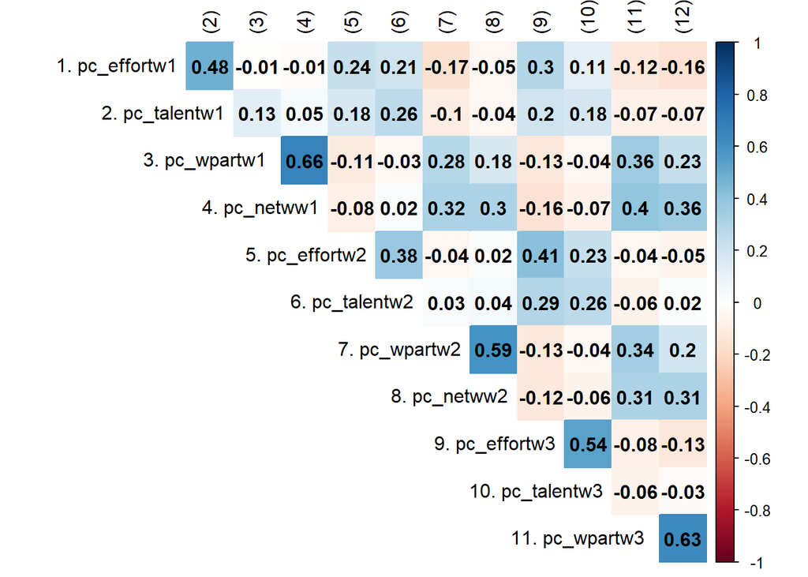

Percepción

```r
corwide02a<- polychoric(x = select(g02 ,starts_with(match = "perc_")),na.rm = T)
rownames(corwide02a$rho) <-c("1. pc_effortw1","2. pc_talentw1","3. pc_wpartw1 ","4. pc_netww1","5. pc_effortw2","6. pc_talentw2","7. pc_wpartw2","8. pc_netww2","9. pc_effortw3","10. pc_talentw3","11. pc_wpartw3 ","12. pc_netww3")
colnames(corwide02a$rho) <-c("(1)", "(2)","(3)","(4)","(5)","(6)","(7)", "(8)","(9)","(10)","(11)","(12)")
corrplot(corwide02a$rho,method = "color", type = "upper", tl.col = "black", addCoef.col = "black",diag = FALSE)
```

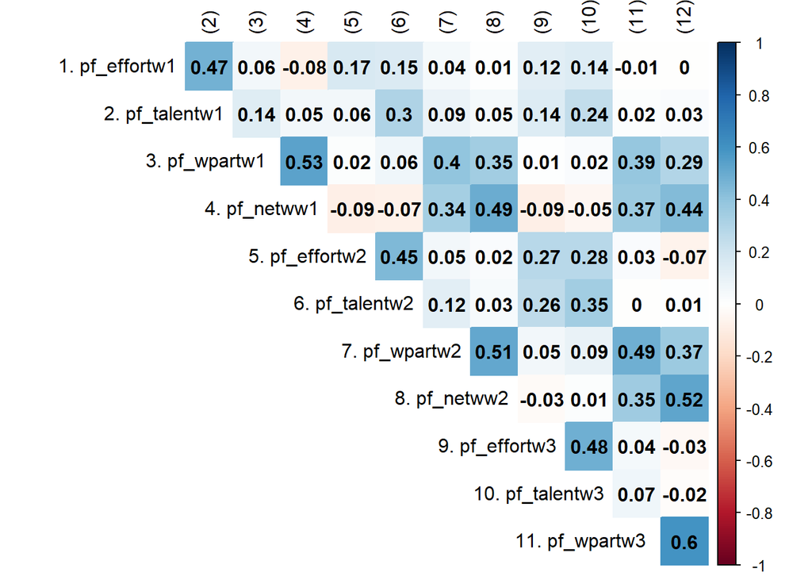

Preferencia

```r
corwide02b<- polychoric(x = select(g02 ,starts_with(match = "pref_")),na.rm = T)
rownames(corwide02b$rho) <-c("1. pf_effortw1","2. pf_talentw1","3. pf_wpartw1 ","4. pf_netww1","5. pf_effortw2","6. pf_talentw2","7. pf_wpartw2","8. pf_netww2","9. pf_effortw3","10. pf_talentw3","11. pf_wpartw3 ","12. pf_netww3")
colnames(corwide02b$rho) <-c("(1)", "(2)","(3)","(4)","(5)","(6)","(7)", "(8)","(9)","(10)","(11)","(12)")
corrplot(corwide02b$rho,method = "color", type = "upper", tl.col = "black", addCoef.col = "black",diag = FALSE)
```

### 1.0.3 Grupo Versión 03

```r
stargazer(g03,type = "html", median = T,digits = 2)
```

| Statistic | N | Mean | St. Dev. | Min | Pctl(25) | Median | Pctl(75) | Max |
| --- | --- | --- | --- | --- | --- | --- | --- | --- |
| perc_effort_w1 | 491 | 3.41 | 1.34 | 1 | 2 | 4 | 5 | 5 |
| perc_talent_w1 | 491 | 3.12 | 1.24 | 1 | 2 | 3 | 4 | 5 |
| perc_wpart_w1 | 491 | 3.76 | 1.34 | 1 | 3 | 4 | 5 | 5 |
| perc_netw_w1 | 491 | 3.92 | 1.22 | 1 | 3 | 4 | 5 | 5 |
| perc_effort_w2 | 491 | 3.32 | 1.24 | 1 | 2 | 4 | 4 | 5 |
| perc_talent_w2 | 491 | 3.13 | 1.09 | 1 | 2 | 3 | 4 | 5 |
| perc_wpart_w2 | 491 | 3.44 | 1.41 | 1 | 2 | 4 | 5 | 5 |
| perc_netw_w2 | 491 | 3.50 | 1.28 | 1 | 3 | 4 | 4 | 5 |
| perc_effort_w3 | 491 | 3.49 | 1.23 | 1 | 3 | 4 | 4.5 | 5 |
| perc_talent_w3 | 491 | 3.21 | 1.01 | 1 | 3 | 3 | 4 | 5 |
| perc_wpart_w3 | 491 | 3.41 | 1.31 | 1 | 3 | 4 | 4 | 5 |
| perc_netw_w3 | 491 | 3.40 | 1.25 | 1 | 3 | 4 | 4 | 5 |
| pref_effort_w1 | 491 | 4.14 | 1.11 | 1 | 4 | 4 | 5 | 5 |
| pref_talent_w1 | 491 | 3.41 | 1.24 | 1 | 3 | 4 | 4 | 5 |
| pref_wpart_w1 | 491 | 2.79 | 1.19 | 1 | 2 | 3 | 4 | 5 |
| pref_netw_w1 | 491 | 2.48 | 1.15 | 1 | 2 | 2 | 3 | 5 |
| pref_effort_w2 | 491 | 3.88 | 1.20 | 1 | 3 | 4 | 5 | 5 |
| pref_talent_w2 | 491 | 3.30 | 1.10 | 1 | 3 | 3 | 4 | 5 |
| pref_wpart_w2 | 491 | 2.58 | 1.16 | 1 | 2 | 3 | 3 | 5 |
| pref_netw_w2 | 491 | 2.32 | 1.04 | 1 | 2 | 2 | 3 | 5 |
| pref_effort_w3 | 491 | 4.05 | 1.08 | 1 | 4 | 4 | 5 | 5 |
| pref_talent_w3 | 491 | 3.45 | 1.09 | 1 | 3 | 3 | 4 | 5 |
| pref_wpart_w3 | 491 | 2.53 | 1.14 | 1 | 2 | 3 | 3 | 5 |
| pref_netw_w3 | 491 | 2.34 | 1.07 | 1 | 1 | 2 | 3 | 5 |

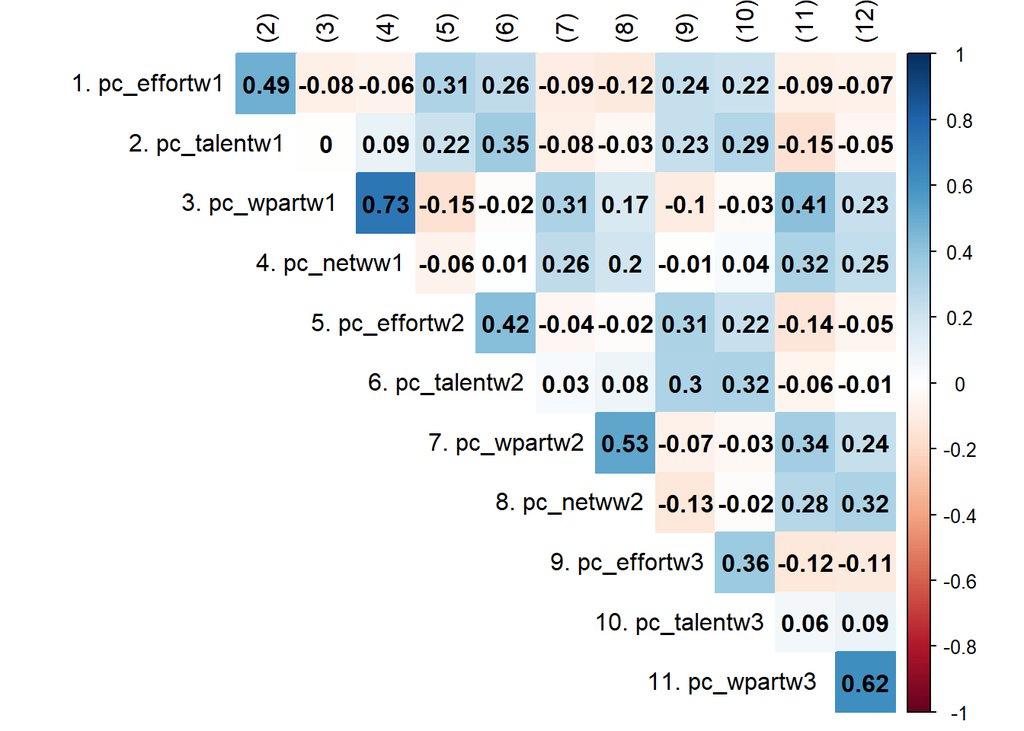

Percepción

```r
corwide03a<- polychoric(x = select(g03 ,starts_with(match = "perc_")),na.rm = T)
rownames(corwide03a$rho) <-c("1. pc_effortw1","2. pc_talentw1","3. pc_wpartw1 ","4. pc_netww1","5. pc_effortw2","6. pc_talentw2","7. pc_wpartw2","8. pc_netww2","9. pc_effortw3","10. pc_talentw3","11. pc_wpartw3 ","12. pc_netww3")
colnames(corwide03a$rho) <-c("(1)", "(2)","(3)","(4)","(5)","(6)","(7)", "(8)","(9)","(10)","(11)","(12)")
corrplot(corwide03a$rho,method = "color", type = "upper", tl.col = "black", addCoef.col = "black",diag = FALSE)
```

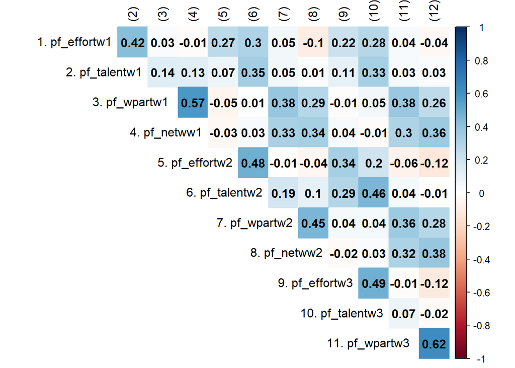

Preferencia

```r
corwide03b<- polychoric(x = select(g03 ,starts_with(match = "pref_")),na.rm = T)
rownames(corwide03b$rho) <-c("1. pf_effortw1","2. pf_talentw1","3. pf_wpartw1 ","4. pf_netww1","5. pf_effortw2","6. pf_talentw2","7. pf_wpartw2","8. pf_netww2","9. pf_effortw3","10. pf_talentw3","11. pf_wpartw3 ","12. pf_netww3")
colnames(corwide03b$rho) <-c("(1)", "(2)","(3)","(4)","(5)","(6)","(7)", "(8)","(9)","(10)","(11)","(12)")
corrplot(corwide03b$rho,method = "color", type = "upper", tl.col = "black", addCoef.col = "black",diag = FALSE)
```

### 1.0.4 Muestra completa

```r
stargazer(select(wide02 ,starts_with(match = "perc_"), starts_with("pref_")),type = "html", median = T,digits = 2)
```

| Statistic | N | Mean | St. Dev. | Min | Pctl(25) | Median | Pctl(75) | Max |
| --- | --- | --- | --- | --- | --- | --- | --- | --- |
| perc_effort_w1 | 1,448 | 3.24 | 1.38 | 1 | 2 | 3 | 4 | 5 |
| perc_talent_w1 | 1,448 | 3.08 | 1.16 | 1 | 2 | 3 | 4 | 5 |
| perc_wpart_w1 | 1,448 | 3.67 | 1.35 | 1 | 3 | 4 | 5 | 5 |
| perc_netw_w1 | 1,448 | 3.79 | 1.23 | 1 | 3 | 4 | 5 | 5 |
| perc_effort_w2 | 1,448 | 3.33 | 1.24 | 1 | 2 | 4 | 4 | 5 |
| perc_talent_w2 | 1,448 | 3.13 | 1.09 | 1 | 2 | 3 | 4 | 5 |
| perc_wpart_w2 | 1,448 | 3.54 | 1.33 | 1 | 3 | 4 | 5 | 5 |
| perc_netw_w2 | 1,448 | 3.55 | 1.25 | 1 | 3 | 4 | 4 | 5 |
| perc_effort_w3 | 1,448 | 3.50 | 1.20 | 1 | 3 | 4 | 4 | 5 |
| perc_talent_w3 | 1,448 | 3.20 | 1.03 | 1 | 3 | 3 | 4 | 5 |
| perc_wpart_w3 | 1,448 | 3.40 | 1.29 | 1 | 3 | 4 | 4 | 5 |
| perc_netw_w3 | 1,448 | 3.45 | 1.24 | 1 | 3 | 4 | 4 | 5 |
| pref_effort_w1 | 1,448 | 3.93 | 1.24 | 1 | 3 | 4 | 5 | 5 |
| pref_talent_w1 | 1,448 | 3.31 | 1.18 | 1 | 3 | 3 | 4 | 5 |
| pref_wpart_w1 | 1,448 | 2.70 | 1.18 | 1 | 2 | 3 | 4 | 5 |
| pref_netw_w1 | 1,448 | 2.39 | 1.10 | 1 | 1.8 | 2 | 3 | 5 |
| pref_effort_w2 | 1,448 | 3.93 | 1.16 | 1 | 3 | 4 | 5 | 5 |
| pref_talent_w2 | 1,448 | 3.29 | 1.12 | 1 | 3 | 3 | 4 | 5 |
| pref_wpart_w2 | 1,448 | 2.59 | 1.15 | 1 | 2 | 3 | 3 | 5 |
| pref_netw_w2 | 1,448 | 2.30 | 1.05 | 1 | 1 | 2 | 3 | 5 |
| pref_effort_w3 | 1,448 | 4.06 | 1.09 | 1 | 4 | 4 | 5 | 5 |
| pref_talent_w3 | 1,448 | 3.46 | 1.07 | 1 | 3 | 4 | 4 | 5 |
| pref_wpart_w3 | 1,448 | 2.53 | 1.15 | 1 | 2 | 3 | 3 | 5 |
| pref_netw_w3 | 1,448 | 2.32 | 1.07 | 1 | 1 | 2 | 3 | 5 |

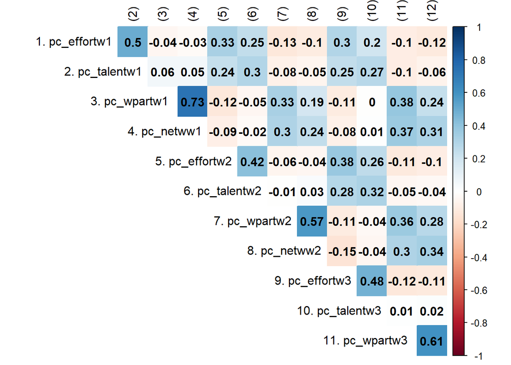

Percepción

```r
corwideA<- polychoric(x = select(wide02 ,starts_with(match = "perc_")),na.rm = T)
rownames(corwideA$rho) <-c("1. pc_effortw1","2. pc_talentw1","3. pc_wpartw1 ","4. pc_netww1","5. pc_effortw2","6. pc_talentw2","7. pc_wpartw2","8. pc_netww2","9. pc_effortw3","10. pc_talentw3","11. pc_wpartw3 ","12. pc_netww3")
colnames(corwideA$rho) <-c("(1)", "(2)","(3)","(4)","(5)","(6)","(7)", "(8)","(9)","(10)","(11)","(12)")
corrplot(corwideA$rho,method = "color", type = "upper", tl.col = "black", addCoef.col = "black",diag = FALSE)
```

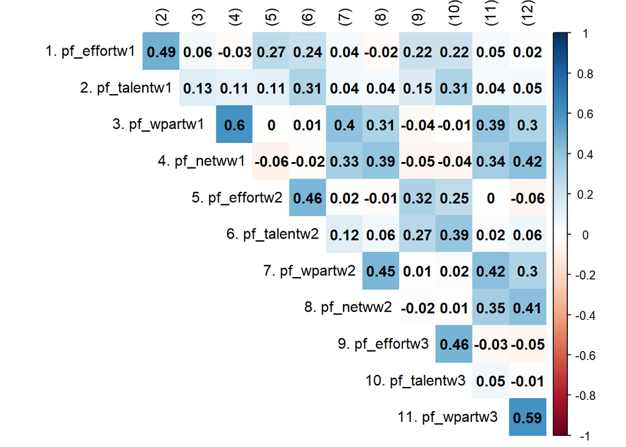

Preferencia

```r
corwideB<- polychoric(x = select(wide02 ,starts_with(match = "pref_")),na.rm = T)
rownames(corwideB$rho) <-c("1. pf_effortw1","2. pf_talentw1","3. pf_wpartw1 ","4. pf_netww1","5. pf_effortw2","6. pf_talentw2","7. pf_wpartw2","8. pf_netww2","9. pf_effortw3","10. pf_talentw3","11. pf_wpartw3 ","12. pf_netww3")
colnames(corwideB$rho) <-c("(1)", "(2)","(3)","(4)","(5)","(6)","(7)", "(8)","(9)","(10)","(11)","(12)")
corrplot(corwideB$rho,method = "color", type = "upper", tl.col = "black", addCoef.col = "black",diag = FALSE)
```

## 1.1 CFA wave01, wave02 y wave03

```r
model_long <- '
# wave 01
perc_merit1 =~perc_effort_w1+perc_talent_w1
perc_nmerit1=~perc_wpart_w1 +perc_netw_w1
pref_merit1 =~pref_effort_w1+pref_talent_w1
pref_nmerit1=~pref_wpart_w1 +pref_netw_w1
# wave 02
perc_merit2 =~perc_effort_w2+perc_talent_w2
perc_nmerit2=~perc_wpart_w2 +perc_netw_w2
pref_merit2 =~pref_effort_w2+pref_talent_w2
pref_nmerit2=~pref_wpart_w2 +pref_netw_w2
# wave 03
perc_merit3 =~perc_effort_w3+perc_talent_w3
perc_nmerit3=~perc_wpart_w3 +perc_netw_w3
pref_merit3 =~pref_effort_w3+pref_talent_w3
pref_nmerit3=~pref_wpart_w3 +pref_netw_w3
'

fitlong_c <- cfa(model = model_long,data = wide02,estimator="MLR") # Continuous/ estimador ML Robust

Indicatores <-c("perc_effort_w1","perc_talent_w1","perc_wpart_w1","perc_netw_w1",
                "pref_effort_w1","pref_talent_w1","pref_wpart_w1","pref_netw_w1",
                "perc_effort_w2","perc_talent_w2","perc_wpart_w2","perc_netw_w2",
                "pref_effort_w2","pref_talent_w2","pref_wpart_w2","pref_netw_w2")

fitlong_o <- cfa(model = model_long,data = wide02,ordered = Indicatores)

#---------------------------------------------------#
kable(rbind(Continuous=fitmeasures(fitlong_c)[c("chisq.scaled","df","cfi","cfi.scaled","cfi.robust","rmsea","rmsea.scaled","rmsea.robust")],
            ordinal= fitmeasures(fitlong_o)[c("chisq.scaled","df","cfi","cfi.scaled","cfi.robust","rmsea","rmsea.scaled","rmsea.robust")]),
      format = "markdown",digits = 3)
```

|  | chisq.scaled | df | cfi | cfi.scaled | cfi.robust | rmsea | rmsea.scaled | rmsea.robust |
| --- | --- | --- | --- | --- | --- | --- | --- | --- |
| Continuous | 665.880 | 186 | 0.930 | 0.930 | 0.933 | 0.046 | 0.042 | 0.045 |
| ordinal | 747.481 | 186 | 0.983 | 0.947 |  | 0.036 | 0.046 |  |

```r
cnames <- c("Factor","Indicator","Loading (MLR)","Loading (DWLS)")
kable(left_join(x = standardizedsolution(fitlong_c) %>% filter(op=="=~") %>% select(lhs,rhs,est.std),
                y = standardizedsolution(fitlong_o) %>% filter(op=="=~") %>% select(lhs,rhs,est.std),
                c("lhs","rhs")),
      format = "markdown",digits = 2,col.names = cnames)
```

| Factor | Indicator | Loading (MLR) | Loading (DWLS) |
| --- | --- | --- | --- |
| perc_merit1 | perc_effort_w1 | 0.69 | 0.70 |
| perc_merit1 | perc_talent_w1 | 0.64 | 0.71 |
| perc_nmerit1 | perc_wpart_w1 | 0.78 | 0.83 |
| perc_nmerit1 | perc_netw_w1 | 0.83 | 0.88 |
| pref_merit1 | pref_effort_w1 | 0.70 | 0.75 |
| pref_merit1 | pref_talent_w1 | 0.59 | 0.65 |
| pref_nmerit1 | pref_wpart_w1 | 0.73 | 0.76 |
| pref_nmerit1 | pref_netw_w1 | 0.74 | 0.79 |
| perc_merit2 | perc_effort_w2 | 0.63 | 0.65 |
| perc_merit2 | perc_talent_w2 | 0.59 | 0.64 |
| perc_nmerit2 | perc_wpart_w2 | 0.73 | 0.81 |
| perc_nmerit2 | perc_netw_w2 | 0.67 | 0.71 |
| pref_merit2 | pref_effort_w2 | 0.62 | 0.65 |
| pref_merit2 | pref_talent_w2 | 0.64 | 0.71 |
| pref_nmerit2 | pref_wpart_w2 | 0.64 | 0.68 |
| pref_nmerit2 | pref_netw_w2 | 0.61 | 0.67 |
| perc_merit3 | perc_effort_w3 | 0.69 | 0.67 |
| perc_merit3 | perc_talent_w3 | 0.62 | 0.64 |
| perc_nmerit3 | perc_wpart_w3 | 0.77 | 0.78 |
| perc_nmerit3 | perc_netw_w3 | 0.69 | 0.69 |
| pref_merit3 | pref_effort_w3 | 0.64 | 0.60 |
| pref_merit3 | pref_talent_w3 | 0.61 | 0.65 |
| pref_nmerit3 | pref_wpart_w3 | 0.75 | 0.74 |
| pref_nmerit3 | pref_netw_w3 | 0.71 | 0.72 |

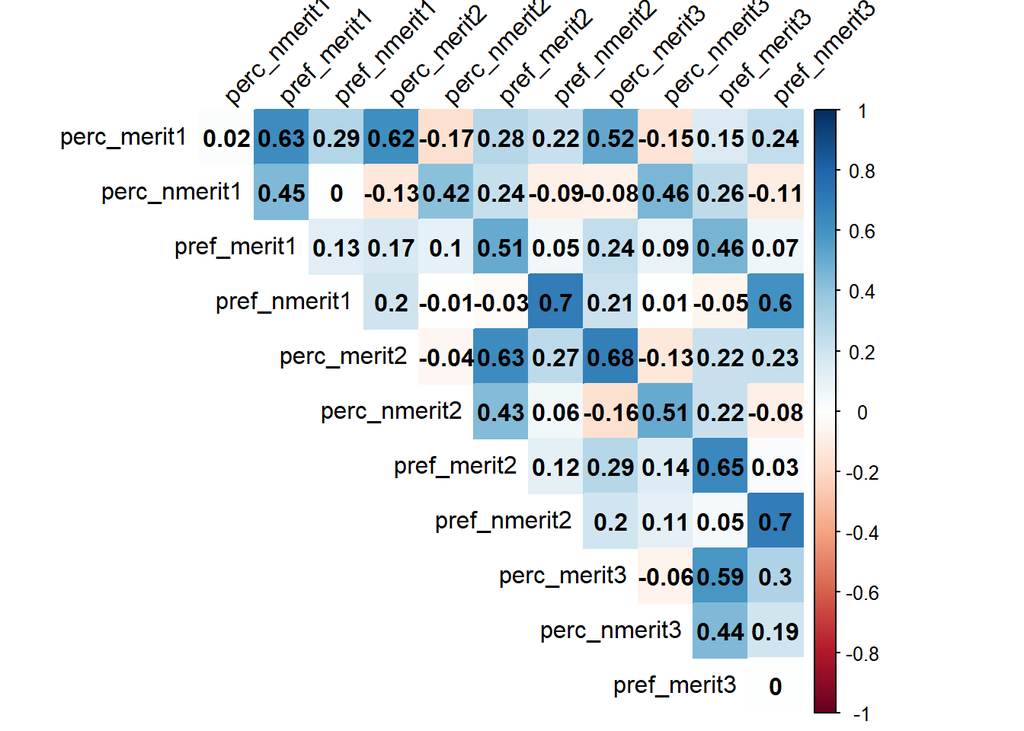

Correlación entre variables latentes w01, w02 y w03

```r
cormat<- as.matrix(inspect(fitlong_o, "cor.lv"))
corrplot(cormat, method = "color" ,type = "upper", tl.col = "black", tl.srt = 45,addCoef.col = "black",diag = FALSE)
```

# 2 Invarianza

## 2.1 Invarianza entre modalidades en ola 1,2 y 3 (between groups invariance)

**NOTE**: En vista de que no existe una librería que permita estimar invarianza longitudinal asumiendo Indicatores ordinales, las primeras estimaciones las realizaré asumiendo Indicatores Continuouss (estimator=MLR).

```r
library(semTools)
```

```r
load(file = "input/data/proc/datalong.RData")     # Datos formato long
load(file = "input/data/proc/datawide_123.RData") # Datos formato wide 3 olas
load(file = "input/data/proc/dat04.RData")

wide_m1 <- subset(wide02,grupo==1) # subset for mode 01
wide_m2 <- subset(wide02,grupo==2) # subset for mode 02
wide_m3 <- subset(wide02,grupo==3) # subset for mode 03
```

```r
m_inv_modalidad <- 'perc_merit=~ perc_effort+perc_talent
                    perc_nmerit=~perc_wpart +perc_netw
                    pref_merit=~ pref_effort+pref_talent
                    pref_nmerit=~pref_wpart +pref_netw'

indicators  <-c("perc_effort","perc_talent","perc_wpart","perc_netw",
                "pref_effort","pref_talent","pref_wpart","pref_netw")

fit.conf=cfa(m_inv_modalidad,data=dat04,group="grupo",estimator="MLR")
fit.deb =cfa(m_inv_modalidad,data=dat04,group="grupo",group.equal=c("loadings"),estimator="MLR")
fit.fuer=cfa(m_inv_modalidad,data=dat04,group="grupo",group.equal=c("loadings","intercepts"),estimator="MLR")
fit.str =cfa(m_inv_modalidad,data=dat04,group="grupo",group.equal=c("loadings","intercepts","residuals"),estimator="MLR")
```

```r
kable(rbind(fit.conf=fitmeasures(fit.conf)[c("chisq.scaled","df","cfi","cfi.scaled","cfi.robust","rmsea","rmsea.scaled","rmsea.robust")],
            fit.deb =fitmeasures(fit.deb )[c("chisq.scaled","df","cfi","cfi.scaled","cfi.robust","rmsea","rmsea.scaled","rmsea.robust")],
            fit.fuer=fitmeasures(fit.fuer)[c("chisq.scaled","df","cfi","cfi.scaled","cfi.robust","rmsea","rmsea.scaled","rmsea.robust")],
            fit.str =fitmeasures(fit.str )[c("chisq.scaled","df","cfi","cfi.scaled","cfi.robust","rmsea","rmsea.scaled","rmsea.robust")]),digits = 3,format = "markdown")
```

|  | chisq.scaled | df | cfi | cfi.scaled | cfi.robust | rmsea | rmsea.scaled | rmsea.robust |
| --- | --- | --- | --- | --- | --- | --- | --- | --- |
| fit.conf | 202.373 | 42 | 0.955 | 0.947 | 0.955 | 0.076 | 0.073 | 0.075 |
| fit.deb | 223.879 | 50 | 0.949 | 0.943 | 0.950 | 0.074 | 0.070 | 0.073 |
| fit.fuer | 238.520 | 58 | 0.947 | 0.940 | 0.948 | 0.070 | 0.066 | 0.069 |
| fit.str | 343.636 | 74 | 0.919 | 0.911 | 0.921 | 0.077 | 0.071 | 0.076 |

```r
kable(anova(fit.conf, fit.deb, fit.fuer, fit.str),format = "markdown",digits = 3)
```

|  | Df | AIC | BIC | Chisq | Chisq diff | Df diff | Pr(>Chisq) |
| --- | --- | --- | --- | --- | --- | --- | --- |
| fit.conf | 42 | 52067.51 | 52577.73 | 214.026 |  |  |  |
| fit.deb | 50 | 52084.09 | 52548.96 | 246.605 | 24.456 | 8 | 0.002 |
| fit.fuer | 58 | 52080.55 | 52500.05 | 259.057 | 12.580 | 8 | 0.127 |
| fit.str | 74 | 52173.19 | 52502.00 | 383.703 | 101.575 | 16 | 0.000 |

## 2.2 Invarianza Longitudinal

> Adapted from Templin (2018), consulted at 24th of march of 2020 from: [here](https://jonathantemplin.com/wp-content/uploads/2017/08/EPSY906_Example07b_CFA_Longitudinal_Invariance.nb_.html)

### 2.2.1 1. Configural Longitudinal Invariance Model (everything separate across time)

```r
configuralSyntax = "
#===================================================================================================
#Factor loadings all freely estimated in each group with labels
perc_merit1  =~ L1T1*perc_effort_w1 + L2T1*perc_talent_w1
perc_merit2  =~ L1T2*perc_effort_w2 + L2T2*perc_talent_w2
perc_merit3  =~ L1T3*perc_effort_w3 + L2T3*perc_talent_w3

perc_nmerit1 =~ L3T1*perc_wpart_w1  + L4T1*perc_netw_w1
perc_nmerit2 =~ L3T2*perc_wpart_w2  + L4T2*perc_netw_w2
perc_nmerit3 =~ L3T3*perc_wpart_w3  + L4T3*perc_netw_w3

pref_merit1  =~ L5T1*pref_effort_w1 + L6T1*pref_talent_w1
pref_merit2  =~ L5T2*pref_effort_w2 + L6T2*pref_talent_w2
pref_merit3  =~ L5T3*pref_effort_w3 + L6T3*pref_talent_w3

pref_nmerit1 =~ L7T1*pref_wpart_w1 + L8T1*pref_netw_w1
pref_nmerit2 =~ L7T2*pref_wpart_w2 + L8T2*pref_netw_w2
pref_nmerit3 =~ L7T3*pref_wpart_w3 + L8T3*pref_netw_w3

#===================================================================================================
#Item intercepts all freely estimated in each group with labels (8 items for each wave 8x3 = 16 intercepts)
perc_effort_w1 ~ I1T1*1; perc_talent_w1 ~ I2T1*1; perc_wpart_w1 ~ I3T1*1; perc_netw_w1 ~ I4T1*1; pref_effort_w1 ~ I5T1*1; pref_talent_w1 ~ I6T1*1; pref_wpart_w1 ~ I7T1*1; pref_netw_w1 ~ I8T1*1;
perc_effort_w2 ~ I1T2*1; perc_talent_w2 ~ I2T2*1; perc_wpart_w2 ~ I3T2*1; perc_netw_w2 ~ I4T2*1; pref_effort_w2 ~ I5T2*1; pref_talent_w2 ~ I6T2*1; pref_wpart_w2 ~ I7T2*1; pref_netw_w2 ~ I8T2*1;
perc_effort_w3 ~ I1T3*1; perc_talent_w3 ~ I2T3*1; perc_wpart_w3 ~ I3T3*1; perc_netw_w3 ~ I4T3*1; pref_effort_w3 ~ I5T3*1; pref_talent_w3 ~ I6T3*1; pref_wpart_w3 ~ I7T3*1; pref_netw_w3 ~ I8T3*1;

#===================================================================================================
#Residual variances all freely estimated in each group with labels
perc_effort_w1 ~~ E1T1*perc_effort_w1; perc_talent_w1 ~~ E2T1*perc_talent_w1; perc_wpart_w1 ~~ E3T1*perc_wpart_w1; perc_netw_w1 ~~ E4T1*perc_netw_w1; pref_effort_w1 ~~ E5T1*pref_effort_w1; pref_talent_w1 ~~ E6T1*pref_talent_w1; pref_wpart_w1 ~~ E7T1*pref_wpart_w1; pref_netw_w1 ~~ E8T1*pref_netw_w1;
perc_effort_w2 ~~ E1T2*perc_effort_w2; perc_talent_w2 ~~ E2T2*perc_talent_w2; perc_wpart_w2 ~~ E3T2*perc_wpart_w2; perc_netw_w2 ~~ E4T2*perc_netw_w2; pref_effort_w2 ~~ E5T2*pref_effort_w2; pref_talent_w2 ~~ E6T2*pref_talent_w2; pref_wpart_w2 ~~ E7T2*pref_wpart_w2; pref_netw_w2 ~~ E8T2*pref_netw_w2;
perc_effort_w3 ~~ E1T3*perc_effort_w3; perc_talent_w3 ~~ E2T3*perc_talent_w3; perc_wpart_w3 ~~ E3T3*perc_wpart_w3; perc_netw_w3 ~~ E4T3*perc_netw_w3; pref_effort_w3 ~~ E5T3*pref_effort_w3; pref_talent_w3 ~~ E6T3*pref_talent_w3; pref_wpart_w3 ~~ E7T3*pref_wpart_w3; pref_netw_w3 ~~ E8T2*pref_netw_w3;
#===================================================================================================
#Residual covariances freely estimated in each group with labels (C1T12= covariance 1 between time 1&2)

perc_effort_w1 ~~ C1T12*perc_effort_w2 + C1T13*perc_effort_w3; perc_effort_w2 ~~ C1T23*perc_effort_w3;
perc_talent_w1 ~~ C2T12*perc_talent_w2 + C2T13*perc_talent_w3; perc_talent_w2 ~~ C2T23*perc_talent_w3;
perc_wpart_w1  ~~ C3T12*perc_wpart_w2  + C3T13*perc_wpart_w3 ; perc_wpart_w2  ~~ C3T23*perc_wpart_w3 ;
perc_netw_w1   ~~ C4T12*perc_netw_w2   + C4T13*perc_netw_w3  ; perc_netw_w2   ~~ C4T23*perc_netw_w3  ;
pref_effort_w1 ~~ C5T12*pref_effort_w2 + C5T13*pref_effort_w3; pref_effort_w2 ~~ C5T23*pref_effort_w3;
pref_talent_w1 ~~ C6T12*pref_talent_w2 + C6T13*pref_talent_w3; pref_talent_w2 ~~ C6T23*pref_talent_w3;
pref_wpart_w1  ~~ C7T12*pref_wpart_w2  + C7T13*pref_wpart_w3 ; pref_wpart_w2  ~~ C7T23*pref_wpart_w3 ;
pref_netw_w1   ~~ C8T12*pref_netw_w2   + C8T13*pref_netw_w3  ; pref_netw_w2   ~~ C8T23*pref_netw_w3  ;


#===================================================================================================
#Factor variance fixed to 1 for identification in each group
perc_merit1  ~~ 1*perc_merit1
perc_merit2  ~~ 1*perc_merit2
perc_merit3  ~~ 1*perc_merit3

perc_nmerit1 ~~ 1*perc_nmerit1
perc_nmerit2 ~~ 1*perc_nmerit2
perc_nmerit3 ~~ 1*perc_nmerit3

pref_merit1  ~~ 1*pref_merit1
pref_merit2  ~~ 1*pref_merit2
pref_merit3  ~~ 1*pref_merit3

pref_nmerit1 ~~ 1*pref_nmerit1
pref_nmerit2 ~~ 1*pref_nmerit2
pref_nmerit3 ~~ 1*pref_nmerit3

#===================================================================================================
#Factor mean fixed to zero for identification in each group
perc_merit1  ~ 0
perc_merit2  ~ 0
perc_merit3  ~ 0

perc_nmerit1 ~ 0
perc_nmerit2 ~ 0
perc_nmerit3 ~ 0

pref_merit1  ~ 0
pref_merit2  ~ 0
pref_merit3  ~ 0

pref_nmerit1 ~ 0
pref_nmerit2 ~ 0
pref_nmerit3 ~ 0

#===================================================================================================
#Factor covariances all freely estimated
perc_merit1  ~~ perc_merit2 + perc_merit3
perc_merit2  ~~ perc_merit3

perc_nmerit1 ~~ perc_nmerit2 + perc_nmerit3
perc_nmerit2 ~~ perc_nmerit3

pref_merit1  ~~ pref_merit2 + pref_merit3
pref_merit2  ~~ pref_merit3

pref_nmerit1 ~~ pref_nmerit2 + pref_nmerit3
pref_nmerit2 ~~ pref_nmerit3
#===================================================================================================
"
```

```r
#configural invariance for mode 01
conf_m1 = lavaan(model = configuralSyntax, data = wide_m1, estimator = "MLR")
```

```r
#configural invariance for mode 02
conf_m2 = lavaan(model = configuralSyntax, data = wide_m2, estimator = "MLR")
```

```r
#configural invariance for mode 03
conf_m3 = lavaan(model = configuralSyntax, data = wide_m3, estimator = "MLR")
```

```r
#configural invariance for complete sample (mode 1, 2 & 3)
conf = lavaan(model = configuralSyntax, data = wide02, estimator = "MLR")
```

```r
kable(rbind(fit.conf=fitmeasures(conf)[c("chisq.scaled","df","cfi","cfi.scaled","cfi.robust","rmsea","rmsea.scaled","rmsea.robust")]),format = "markdown",digits = 3)
```

|  | chisq.scaled | df | cfi | cfi.scaled | cfi.robust | rmsea | rmsea.scaled | rmsea.robust |
| --- | --- | --- | --- | --- | --- | --- | --- | --- |
| fit.conf | 1514.4 | 217 | 0.813 | 0.81 | 0.816 | 0.07 | 0.064 | 0.069 |

### 2.2.2 2. Metric Invariance Models (ALL loadings held equal across time - identified model using Time1 Factor Variance = 1)

```r
metricSyntax1 = "
#===================================================================================================
#Factor loadings all constrained across groups with labels *****
perc_merit1  =~ L1*perc_effort_w1 + L2*perc_talent_w1
perc_merit2  =~ L1*perc_effort_w2 + L2*perc_talent_w2
perc_merit3  =~ L1*perc_effort_w3 + L2*perc_talent_w3

perc_nmerit1 =~ L3*perc_wpart_w1  + L4*perc_netw_w1
perc_nmerit2 =~ L3*perc_wpart_w2  + L4*perc_netw_w2
perc_nmerit3 =~ L3*perc_wpart_w3  + L4*perc_netw_w3

pref_merit1  =~ L5*pref_effort_w1 + L6*pref_talent_w1
pref_merit2  =~ L5*pref_effort_w2 + L6*pref_talent_w2
pref_merit3  =~ L5*pref_effort_w3 + L6*pref_talent_w3

pref_nmerit1 =~ L7*pref_wpart_w1 + L8*pref_netw_w1
pref_nmerit2 =~ L7*pref_wpart_w2 + L8*pref_netw_w2
pref_nmerit3 =~ L7*pref_wpart_w3 + L8*pref_netw_w3

#===================================================================================================
#Item intercepts all freely estimated in each group with labels (8 items for each wave 8x3 = 16 intercepts)
perc_effort_w1 ~ I1T1*1; perc_talent_w1 ~ I2T1*1; perc_wpart_w1 ~ I3T1*1; perc_netw_w1 ~ I4T1*1; pref_effort_w1 ~ I5T1*1; pref_talent_w1 ~ I6T1*1; pref_wpart_w1 ~ I7T1*1; pref_netw_w1 ~ I8T1*1;
perc_effort_w2 ~ I1T2*1; perc_talent_w2 ~ I2T2*1; perc_wpart_w2 ~ I3T2*1; perc_netw_w2 ~ I4T2*1; pref_effort_w2 ~ I5T2*1; pref_talent_w2 ~ I6T2*1; pref_wpart_w2 ~ I7T2*1; pref_netw_w2 ~ I8T2*1;
perc_effort_w3 ~ I1T3*1; perc_talent_w3 ~ I2T3*1; perc_wpart_w3 ~ I3T3*1; perc_netw_w3 ~ I4T3*1; pref_effort_w3 ~ I5T3*1; pref_talent_w3 ~ I6T3*1; pref_wpart_w3 ~ I7T3*1; pref_netw_w3 ~ I8T3*1;

#===================================================================================================
#Residual variances all freely estimated in each group with labels
perc_effort_w1 ~~ E1T1*perc_effort_w1; perc_talent_w1 ~~ E2T1*perc_talent_w1; perc_wpart_w1 ~~ E3T1*perc_wpart_w1; perc_netw_w1 ~~ E4T1*perc_netw_w1; pref_effort_w1 ~~ E5T1*pref_effort_w1; pref_talent_w1 ~~ E6T1*pref_talent_w1; pref_wpart_w1 ~~ E7T1*pref_wpart_w1; pref_netw_w1 ~~ E8T1*pref_netw_w1;
perc_effort_w2 ~~ E1T2*perc_effort_w2; perc_talent_w2 ~~ E2T2*perc_talent_w2; perc_wpart_w2 ~~ E3T2*perc_wpart_w2; perc_netw_w2 ~~ E4T2*perc_netw_w2; pref_effort_w2 ~~ E5T2*pref_effort_w2; pref_talent_w2 ~~ E6T2*pref_talent_w2; pref_wpart_w2 ~~ E7T2*pref_wpart_w2; pref_netw_w2 ~~ E8T2*pref_netw_w2;
perc_effort_w3 ~~ E1T3*perc_effort_w3; perc_talent_w3 ~~ E2T3*perc_talent_w3; perc_wpart_w3 ~~ E3T3*perc_wpart_w3; perc_netw_w3 ~~ E4T3*perc_netw_w3; pref_effort_w3 ~~ E5T3*pref_effort_w3; pref_talent_w3 ~~ E6T3*pref_talent_w3; pref_wpart_w3 ~~ E7T3*pref_wpart_w3; pref_netw_w3 ~~ E8T2*pref_netw_w3;
#===================================================================================================
#Residual covariances freely estimated in each group with labels (C1T12= covariance 1 between time 1&2)

perc_effort_w1 ~~ C1T12*perc_effort_w2 + C1T13*perc_effort_w3; perc_effort_w2 ~~ C1T23*perc_effort_w3;
perc_talent_w1 ~~ C2T12*perc_talent_w2 + C2T13*perc_talent_w3; perc_talent_w2 ~~ C2T23*perc_talent_w3;
perc_wpart_w1  ~~ C3T12*perc_wpart_w2  + C3T13*perc_wpart_w3 ; perc_wpart_w2  ~~ C3T23*perc_wpart_w3 ;
perc_netw_w1   ~~ C4T12*perc_netw_w2   + C4T13*perc_netw_w3  ; perc_netw_w2   ~~ C4T23*perc_netw_w3  ;
pref_effort_w1 ~~ C5T12*pref_effort_w2 + C5T13*pref_effort_w3; pref_effort_w2 ~~ C5T23*pref_effort_w3;
pref_talent_w1 ~~ C6T12*pref_talent_w2 + C6T13*pref_talent_w3; pref_talent_w2 ~~ C6T23*pref_talent_w3;
pref_wpart_w1  ~~ C7T12*pref_wpart_w2  + C7T13*pref_wpart_w3 ; pref_wpart_w2  ~~ C7T23*pref_wpart_w3 ;
pref_netw_w1   ~~ C8T12*pref_netw_w2   + C8T13*pref_netw_w3  ; pref_netw_w2   ~~ C8T23*pref_netw_w3  ;


#===================================================================================================
# Factor variance fixed to 1 for identification in first group; estimated in others *****
perc_merit1  ~~ 1*perc_merit1
perc_merit2  ~~ perc_merit2  # deje fijado la varianza de los factores en 1 (esto lo cambie yo respecto al script original)
perc_merit3  ~~ perc_merit3  # deje fijado la varianza de los factores en 1 (esto lo cambie yo respecto al script original)

perc_nmerit1 ~~ 1*perc_nmerit1
perc_nmerit2 ~~ perc_nmerit2 # deje fijado la varianza de los factores en 1 (esto lo cambie yo respecto al script original)
perc_nmerit3 ~~ perc_nmerit3 # deje fijado la varianza de los factores en 1 (esto lo cambie yo respecto al script original)

pref_merit1  ~~ 1*pref_merit1
pref_merit2  ~~ pref_merit2  # deje fijado la varianza de los factores en 1 (esto lo cambie yo respecto al script original)
pref_merit3  ~~ pref_merit3  # deje fijado la varianza de los factores en 1 (esto lo cambie yo respecto al script original)

pref_nmerit1 ~~ 1*pref_nmerit1
pref_nmerit2 ~~ pref_nmerit2 # deje fijado la varianza de los factores en 1 (esto lo cambie yo respecto al script original)
pref_nmerit3 ~~ pref_nmerit3 # deje fijado la varianza de los factores en 1 (esto lo cambie yo respecto al script original)

#===================================================================================================
#Factor mean fixed to zero for identification in each group
perc_merit1  ~ 0
perc_merit2  ~ 0
perc_merit3  ~ 0

perc_nmerit1 ~ 0
perc_nmerit2 ~ 0
perc_nmerit3 ~ 0

pref_merit1  ~ 0
pref_merit2  ~ 0
pref_merit3  ~ 0

pref_nmerit1 ~ 0
pref_nmerit2 ~ 0
pref_nmerit3 ~ 0

#===================================================================================================
#Factor covariances all freely estimated
perc_merit1  ~~ perc_merit2 + perc_merit3
perc_merit2  ~~ perc_merit3

perc_nmerit1 ~~ perc_nmerit2 + perc_nmerit3
perc_nmerit2 ~~ perc_nmerit3

pref_merit1  ~~ pref_merit2 + pref_merit3
pref_merit2  ~~ pref_merit3

pref_nmerit1 ~~ pref_nmerit2 + pref_nmerit3
pref_nmerit2 ~~ pref_nmerit3
#===================================================================================================
"
```

```r
#metric invariance for mode 01
metr_m1A = lavaan(model = metricSyntax1, data = wide_m1, estimator = "MLR")
```

```r
#metric invariance for mode 02
metr_m2A = lavaan(model = metricSyntax1, data = wide_m2, estimator = "MLR")
```

```r
#metric invariance for mode 03
metr_m3A = lavaan(model = metricSyntax1, data = wide_m3, estimator = "MLR")
```

```r
#metric invariance for complete sample (mode 1, 2 & 3)
metrA = lavaan(model = metricSyntax1, data = wide02, estimator = "MLR")
```

```r
#lavTestLRT(metr_m1A, conf_m1,scaled.shifted = TRUE, method = "satorra.bentler.2001")#conf_m1 was not estimated using scaled (robust) fit measures
# lavTestLRT(metr_m2A, conf_m2,scaled.shifted = TRUE, method = "satorra.bentler.2001") # invariantes
# lavTestLRT(metr_m3A, conf_m3,scaled.shifted = TRUE, method = "satorra.bentler.2001") # invariantes

kable(rbind(fit.conf=fitmeasures(conf)[c("chisq.scaled","df","cfi","cfi.scaled","cfi.robust","rmsea","rmsea.scaled","rmsea.robust")],
            fit.metrA =fitmeasures(metrA)[c("chisq.scaled","df","cfi","cfi.scaled","cfi.robust","rmsea","rmsea.scaled","rmsea.robust")]),digits = 3,format = "markdown")
```

|  | chisq.scaled | df | cfi | cfi.scaled | cfi.robust | rmsea | rmsea.scaled | rmsea.robust |
| --- | --- | --- | --- | --- | --- | --- | --- | --- |
| fit.conf | 1514.400 | 217 | 0.813 | 0.810 | 0.816 | 0.07 | 0.064 | 0.069 |
| fit.metrA | 1547.583 | 225 | 0.810 | 0.807 | 0.813 | 0.07 | 0.064 | 0.069 |

```r
kable(lavTestLRT(metrA,conf,scaled.shifted = TRUE, method = "satorra.bentler.2001"),digits = 3,format = "markdown") # no es invariante, ver modind
```

|  | Df | AIC | BIC | Chisq | Chisq diff | Df diff | Pr(>Chisq) |
| --- | --- | --- | --- | --- | --- | --- | --- |
| conf | 217 | 103397.4 | 103962.2 | 1769.008 |  |  |  |
| metrA | 225 | 103414.3 | 103936.8 | 1801.887 | 30.982 | 8 | 0 |

**Mod Indices**:

```r
#get modification indices for all parameters:
metricMI1 = modificationindices(metrA, free.remove = FALSE, maximum.number = 10000)
#restrict output to only factor loading parameters
metricMI1a = metricMI1[which(metricMI1$op == "=~"),]
#restrict output to only factors and items with same time point
metricMI1a$factorTime = metricMI1a$lhs
#extract time characters from items
metricMI1a$itemTime = ifelse(test =endsWith(x = metricMI1a$rhs,suffix = "w1"),yes = "wave01",
                              no = ifelse(test = endsWith(x = metricMI1a$rhs,suffix = "w2"),yes = "wave02",
                                          no = "wave03"))

metricMI1a$factorTime = ifelse(test =endsWith(x = metricMI1a$lhs,suffix = "1"),yes = "wave01",
                               no = ifelse(test = endsWith(x = metricMI1a$lhs,suffix = "2"),yes = "wave02",
                                           no = "wave03"))
metricMI1a$factor     = ifelse(test =startsWith(x = metricMI1a$lhs,prefix = "perc_merit"),yes = "perc_merit",
                               no = ifelse(test = startsWith(x = metricMI1a$lhs,prefix = "perc_nmerit"),yes = "perc_nmerit",
                                           no = ifelse(test = startsWith(x = metricMI1a$lhs,prefix = "pref_merit"),yes = "pref_merit",
                                                       no = "pref_nmerit" )))

metricMI1a$item     = ifelse(test =startsWith(x = metricMI1a$rhs,prefix = "perc_effort") | startsWith(x = metricMI1a$rhs,prefix = "perc_talent"),yes = "perc_merit",
                               no = ifelse(test = startsWith(x = metricMI1a$rhs,prefix = "perc_wpart")  | startsWith(x = metricMI1a$rhs,prefix = "perc_netw"),yes = "perc_nmerit",
                                           no = ifelse(test = startsWith(x = metricMI1a$rhs,prefix = "pref_effort") | startsWith(x = metricMI1a$rhs,prefix = "pref_talent"),yes = "pref_merit",
                                                       no = "pref_nmerit" )))

metricMI1b<- metricMI1a %>% filter(factorTime==itemTime & factor==item) # quedarme con los que son de la misma ola y mismo factor

#show only MIs for same time
metricMI1b <- metricMI1b[order(-metricMI1b$mi),]
```

```r
metricSyntax2 = "
#===================================================================================================
#Factor loadings all constrained across groups with labels *****
perc_merit1  =~ L1*perc_effort_w1 + L2*perc_talent_w1
perc_merit2  =~ L1*perc_effort_w2 + L2*perc_talent_w2
perc_merit3  =~ L1*perc_effort_w3 + L2*perc_talent_w3
perc_nmerit1 =~ L3*perc_wpart_w1  + L4T1*perc_netw_w1 #FREE PARAMETER
perc_nmerit2 =~ L3*perc_wpart_w2  + L4*perc_netw_w2
perc_nmerit3 =~ L3*perc_wpart_w3  + L4*perc_netw_w3
pref_merit1  =~ L5*pref_effort_w1 + L6*pref_talent_w1
pref_merit2  =~ L5*pref_effort_w2 + L6*pref_talent_w2
pref_merit3  =~ L5*pref_effort_w3 + L6*pref_talent_w3
pref_nmerit1 =~ L7*pref_wpart_w1  + L8*pref_netw_w1
pref_nmerit2 =~ L7*pref_wpart_w2  + L8*pref_netw_w2
pref_nmerit3 =~ L7*pref_wpart_w3  + L8*pref_netw_w3

#===================================================================================================
#Item intercepts all freely estimated in each group with labels (8 items for each wave 8x3 = 16 intercepts)
perc_effort_w1 ~ I1T1*1; perc_talent_w1 ~ I2T1*1; perc_wpart_w1 ~ I3T1*1; perc_netw_w1 ~ I4T1*1; pref_effort_w1 ~ I5T1*1; pref_talent_w1 ~ I6T1*1; pref_wpart_w1 ~ I7T1*1; pref_netw_w1 ~ I8T1*1;
perc_effort_w2 ~ I1T2*1; perc_talent_w2 ~ I2T2*1; perc_wpart_w2 ~ I3T2*1; perc_netw_w2 ~ I4T2*1; pref_effort_w2 ~ I5T2*1; pref_talent_w2 ~ I6T2*1; pref_wpart_w2 ~ I7T2*1; pref_netw_w2 ~ I8T2*1;
perc_effort_w3 ~ I1T3*1; perc_talent_w3 ~ I2T3*1; perc_wpart_w3 ~ I3T3*1; perc_netw_w3 ~ I4T3*1; pref_effort_w3 ~ I5T3*1; pref_talent_w3 ~ I6T3*1; pref_wpart_w3 ~ I7T3*1; pref_netw_w3 ~ I8T3*1;

#===================================================================================================
#Residual variances all freely estimated in each group with labels
perc_effort_w1 ~~ E1T1*perc_effort_w1; perc_talent_w1 ~~ E2T1*perc_talent_w1; perc_wpart_w1 ~~ E3T1*perc_wpart_w1; perc_netw_w1 ~~ E4T1*perc_netw_w1; pref_effort_w1 ~~ E5T1*pref_effort_w1; pref_talent_w1 ~~ E6T1*pref_talent_w1; pref_wpart_w1 ~~ E7T1*pref_wpart_w1; pref_netw_w1 ~~ E8T1*pref_netw_w1;
perc_effort_w2 ~~ E1T2*perc_effort_w2; perc_talent_w2 ~~ E2T2*perc_talent_w2; perc_wpart_w2 ~~ E3T2*perc_wpart_w2; perc_netw_w2 ~~ E4T2*perc_netw_w2; pref_effort_w2 ~~ E5T2*pref_effort_w2; pref_talent_w2 ~~ E6T2*pref_talent_w2; pref_wpart_w2 ~~ E7T2*pref_wpart_w2; pref_netw_w2 ~~ E8T2*pref_netw_w2;
perc_effort_w3 ~~ E1T3*perc_effort_w3; perc_talent_w3 ~~ E2T3*perc_talent_w3; perc_wpart_w3 ~~ E3T3*perc_wpart_w3; perc_netw_w3 ~~ E4T3*perc_netw_w3; pref_effort_w3 ~~ E5T3*pref_effort_w3; pref_talent_w3 ~~ E6T3*pref_talent_w3; pref_wpart_w3 ~~ E7T3*pref_wpart_w3; pref_netw_w3 ~~ E8T2*pref_netw_w3;
#===================================================================================================
#Residual covariances freely estimated in each group with labels (C1T12= covariance 1 between time 1&2)
perc_effort_w1 ~~ C1T12*perc_effort_w2 + C1T13*perc_effort_w3; perc_effort_w2 ~~ C1T23*perc_effort_w3;
perc_talent_w1 ~~ C2T12*perc_talent_w2 + C2T13*perc_talent_w3; perc_talent_w2 ~~ C2T23*perc_talent_w3;
perc_wpart_w1  ~~ C3T12*perc_wpart_w2  + C3T13*perc_wpart_w3 ; perc_wpart_w2  ~~ C3T23*perc_wpart_w3 ;
perc_netw_w1   ~~ C4T12*perc_netw_w2   + C4T13*perc_netw_w3  ; perc_netw_w2   ~~ C4T23*perc_netw_w3  ;
pref_effort_w1 ~~ C5T12*pref_effort_w2 + C5T13*pref_effort_w3; pref_effort_w2 ~~ C5T23*pref_effort_w3;
pref_talent_w1 ~~ C6T12*pref_talent_w2 + C6T13*pref_talent_w3; pref_talent_w2 ~~ C6T23*pref_talent_w3;
pref_wpart_w1  ~~ C7T12*pref_wpart_w2  + C7T13*pref_wpart_w3 ; pref_wpart_w2  ~~ C7T23*pref_wpart_w3 ;
pref_netw_w1   ~~ C8T12*pref_netw_w2   + C8T13*pref_netw_w3  ; pref_netw_w2   ~~ C8T23*pref_netw_w3  ;

#===================================================================================================
# Factor variance fixed to 1 for identification in first group; estimated in others *****
perc_merit1  ~~ 1*perc_merit1
perc_merit2  ~~ perc_merit2
perc_merit3  ~~ perc_merit3
perc_nmerit1 ~~ 1*perc_nmerit1
perc_nmerit2 ~~ perc_nmerit2
perc_nmerit3 ~~ perc_nmerit3
pref_merit1  ~~ 1*pref_merit1
pref_merit2  ~~ pref_merit2
pref_merit3  ~~ pref_merit3
pref_nmerit1 ~~ 1*pref_nmerit1
pref_nmerit2 ~~ pref_nmerit2
pref_nmerit3 ~~ pref_nmerit3

#===================================================================================================
#Factor mean fixed to zero for identification in each group
perc_merit1  ~ 0
perc_merit2  ~ 0
perc_merit3  ~ 0
perc_nmerit1 ~ 0
perc_nmerit2 ~ 0
perc_nmerit3 ~ 0
pref_merit1  ~ 0
pref_merit2  ~ 0
pref_merit3  ~ 0
pref_nmerit1 ~ 0
pref_nmerit2 ~ 0
pref_nmerit3 ~ 0

#===================================================================================================
#Factor covariances all freely estimated
perc_merit1  ~~ perc_merit2 + perc_merit3
perc_merit2  ~~ perc_merit3
perc_nmerit1 ~~ perc_nmerit2 + perc_nmerit3
perc_nmerit2 ~~ perc_nmerit3
pref_merit1  ~~ pref_merit2 + pref_merit3
pref_merit2  ~~ pref_merit3
pref_nmerit1 ~~ pref_nmerit2 + pref_nmerit3
pref_nmerit2 ~~ pref_nmerit3
"
```

```r
#metric invariance (v02) for complete sample (mode 1, 2 & 3) +  free parameter
metrA2 = lavaan(model = metricSyntax2, data = wide02, estimator = "MLR")

kable(rbind(fit.conf=fitmeasures(conf)[c("chisq.scaled","df","cfi","cfi.scaled","cfi.robust","rmsea","rmsea.scaled","rmsea.robust")],
            fit.metrA =fitmeasures(metrA)[c("chisq.scaled","df","cfi","cfi.scaled","cfi.robust","rmsea","rmsea.scaled","rmsea.robust")],
            fit.metrA2 =fitmeasures(metrA2)[c("chisq.scaled","df","cfi","cfi.scaled","cfi.robust","rmsea","rmsea.scaled","rmsea.robust")]),digits = 3,format = "markdown")
```

|  | chisq.scaled | df | cfi | cfi.scaled | cfi.robust | rmsea | rmsea.scaled | rmsea.robust |
| --- | --- | --- | --- | --- | --- | --- | --- | --- |
| fit.conf | 1514.400 | 217 | 0.813 | 0.810 | 0.816 | 0.070 | 0.064 | 0.069 |
| fit.metrA | 1547.583 | 225 | 0.810 | 0.807 | 0.813 | 0.070 | 0.064 | 0.069 |
| fit.metrA2 | 1532.551 | 224 | 0.812 | 0.809 | 0.815 | 0.069 | 0.064 | 0.069 |

```r
#fit.metrA  = all factor loading restricted
#fit.metrA2 = one free estimated factor loading
kable(lavTestLRT(metrA2,conf,scaled.shifted = TRUE,method = "satorra.bentler.2001"),format = "markdown",digits = 3) #non invariant, see modind metric2 below
```

|  | Df | AIC | BIC | Chisq | Chisq diff | Df diff | Pr(>Chisq) |
| --- | --- | --- | --- | --- | --- | --- | --- |
| conf | 217 | 103397.4 | 103962.2 | 1769.008 |  |  |  |
| metrA2 | 224 | 103399.2 | 103927.0 | 1784.797 | 14.965 | 7 | 0.036 |

**NOTE**: El modelo que deja libre 1 parámetro (metrA2) mejora el ajuste, pero la diff del chi2 sigue siendo significativa al 0.05.

**Mod Indices**:

```r
#get modification indices for all parameters:
metricMI1 = modificationindices(metrA2, free.remove = FALSE, maximum.number = 10000)
#restrict output to only factor loading parameters
metricMI1a = metricMI1[which(metricMI1$op == "=~"),]
#restrict output to only factors and items with same time point
metricMI1a$factorTime = metricMI1a$lhs
#extract time characters from items
metricMI1a$itemTime   = ifelse(test =endsWith(x = metricMI1a$rhs,suffix = "w1"),yes = "wave01",
                                no = ifelse(test = endsWith(x = metricMI1a$rhs,suffix = "w2"),yes = "wave02",
                                            no = "wave03"))

metricMI1a$factorTime = ifelse(test =endsWith(x = metricMI1a$lhs,suffix = "1"),yes = "wave01",
                               no = ifelse(test = endsWith(x = metricMI1a$lhs,suffix = "2"),yes = "wave02",
                                           no = "wave03"))
metricMI1a$factor     = ifelse(test =startsWith(x = metricMI1a$lhs,prefix = "perc_merit"),yes = "perc_merit",
                               no = ifelse(test = startsWith(x = metricMI1a$lhs,prefix = "perc_nmerit"),yes = "perc_nmerit",
                                           no = ifelse(test = startsWith(x = metricMI1a$lhs,prefix = "pref_merit"),yes = "pref_merit",
                                                       no = "pref_nmerit" )))

metricMI1a$item      = ifelse(test =startsWith(x = metricMI1a$rhs,prefix = "perc_effort") | startsWith(x = metricMI1a$rhs,prefix = "perc_talent"),yes = "perc_merit",
                              no = ifelse(test = startsWith(x = metricMI1a$rhs,prefix = "perc_wpart")  | startsWith(x = metricMI1a$rhs,prefix = "perc_netw"),yes = "perc_nmerit",
                                          no = ifelse(test = startsWith(x = metricMI1a$rhs,prefix = "pref_effort") | startsWith(x = metricMI1a$rhs,prefix = "pref_talent"),yes = "pref_merit",
                                                      no = "pref_nmerit" )))

metricMI1b<- metricMI1a %>% filter(factorTime==itemTime & factor==item) # quedarme con los que son de la misma ola y mismo factor

#show only MIs for same time
metricMI1b <- metricMI1b[order(-metricMI1b$mi),]
```

```r
metricSyntax3 = "
#===================================================================================================
#Factor loadings all constrained across groups with labels *****
perc_merit1  =~ L1*perc_effort_w1 + L2*perc_talent_w1
perc_merit2  =~ L1*perc_effort_w2 + L2*perc_talent_w2
perc_merit3  =~ L1*perc_effort_w3 + L2*perc_talent_w3
perc_nmerit1 =~ L3*perc_wpart_w1  + L4T1*perc_netw_w1  #FREE PARAMETER
perc_nmerit2 =~ L3*perc_wpart_w2  + L4*perc_netw_w2
perc_nmerit3 =~ L3*perc_wpart_w3  + L4*perc_netw_w3
pref_merit1  =~ L5*pref_effort_w1 + L6T1*pref_talent_w1 #FREE PARAMETER
pref_merit2  =~ L5*pref_effort_w2 + L6*pref_talent_w2
pref_merit3  =~ L5*pref_effort_w3 + L6*pref_talent_w3
pref_nmerit1 =~ L7*pref_wpart_w1  + L8*pref_netw_w1
pref_nmerit2 =~ L7*pref_wpart_w2  + L8*pref_netw_w2
pref_nmerit3 =~ L7*pref_wpart_w3  + L8*pref_netw_w3

#===================================================================================================
#Item intercepts all freely estimated in each group with labels (8 items for each wave 8x3 = 16 intercepts)
perc_effort_w1 ~ I1T1*1; perc_talent_w1 ~ I2T1*1; perc_wpart_w1 ~ I3T1*1; perc_netw_w1 ~ I4T1*1; pref_effort_w1 ~ I5T1*1; pref_talent_w1 ~ I6T1*1; pref_wpart_w1 ~ I7T1*1; pref_netw_w1 ~ I8T1*1;
perc_effort_w2 ~ I1T2*1; perc_talent_w2 ~ I2T2*1; perc_wpart_w2 ~ I3T2*1; perc_netw_w2 ~ I4T2*1; pref_effort_w2 ~ I5T2*1; pref_talent_w2 ~ I6T2*1; pref_wpart_w2 ~ I7T2*1; pref_netw_w2 ~ I8T2*1;
perc_effort_w3 ~ I1T3*1; perc_talent_w3 ~ I2T3*1; perc_wpart_w3 ~ I3T3*1; perc_netw_w3 ~ I4T3*1; pref_effort_w3 ~ I5T3*1; pref_talent_w3 ~ I6T3*1; pref_wpart_w3 ~ I7T3*1; pref_netw_w3 ~ I8T3*1;

#===================================================================================================
#Residual variances all freely estimated in each group with labels
perc_effort_w1 ~~ E1T1*perc_effort_w1; perc_talent_w1 ~~ E2T1*perc_talent_w1; perc_wpart_w1 ~~ E3T1*perc_wpart_w1; perc_netw_w1 ~~ E4T1*perc_netw_w1; pref_effort_w1 ~~ E5T1*pref_effort_w1; pref_talent_w1 ~~ E6T1*pref_talent_w1; pref_wpart_w1 ~~ E7T1*pref_wpart_w1; pref_netw_w1 ~~ E8T1*pref_netw_w1;
perc_effort_w2 ~~ E1T2*perc_effort_w2; perc_talent_w2 ~~ E2T2*perc_talent_w2; perc_wpart_w2 ~~ E3T2*perc_wpart_w2; perc_netw_w2 ~~ E4T2*perc_netw_w2; pref_effort_w2 ~~ E5T2*pref_effort_w2; pref_talent_w2 ~~ E6T2*pref_talent_w2; pref_wpart_w2 ~~ E7T2*pref_wpart_w2; pref_netw_w2 ~~ E8T2*pref_netw_w2;
perc_effort_w3 ~~ E1T3*perc_effort_w3; perc_talent_w3 ~~ E2T3*perc_talent_w3; perc_wpart_w3 ~~ E3T3*perc_wpart_w3; perc_netw_w3 ~~ E4T3*perc_netw_w3; pref_effort_w3 ~~ E5T3*pref_effort_w3; pref_talent_w3 ~~ E6T3*pref_talent_w3; pref_wpart_w3 ~~ E7T3*pref_wpart_w3; pref_netw_w3 ~~ E8T2*pref_netw_w3;
#===================================================================================================
#Residual covariances freely estimated in each group with labels (C1T12= covariance 1 between time 1&2)
perc_effort_w1 ~~ C1T12*perc_effort_w2 + C1T13*perc_effort_w3; perc_effort_w2 ~~ C1T23*perc_effort_w3;
perc_talent_w1 ~~ C2T12*perc_talent_w2 + C2T13*perc_talent_w3; perc_talent_w2 ~~ C2T23*perc_talent_w3;
perc_wpart_w1  ~~ C3T12*perc_wpart_w2  + C3T13*perc_wpart_w3 ; perc_wpart_w2  ~~ C3T23*perc_wpart_w3 ;
perc_netw_w1   ~~ C4T12*perc_netw_w2   + C4T13*perc_netw_w3  ; perc_netw_w2   ~~ C4T23*perc_netw_w3  ;
pref_effort_w1 ~~ C5T12*pref_effort_w2 + C5T13*pref_effort_w3; pref_effort_w2 ~~ C5T23*pref_effort_w3;
pref_talent_w1 ~~ C6T12*pref_talent_w2 + C6T13*pref_talent_w3; pref_talent_w2 ~~ C6T23*pref_talent_w3;
pref_wpart_w1  ~~ C7T12*pref_wpart_w2  + C7T13*pref_wpart_w3 ; pref_wpart_w2  ~~ C7T23*pref_wpart_w3 ;
pref_netw_w1   ~~ C8T12*pref_netw_w2   + C8T13*pref_netw_w3  ; pref_netw_w2   ~~ C8T23*pref_netw_w3  ;

#===================================================================================================
# Factor variance fixed to 1 for identification in first group; estimated in others *****
perc_merit1  ~~ 1*perc_merit1
perc_merit2  ~~ perc_merit2
perc_merit3  ~~ perc_merit3
perc_nmerit1 ~~ 1*perc_nmerit1
perc_nmerit2 ~~ perc_nmerit2
perc_nmerit3 ~~ perc_nmerit3
pref_merit1  ~~ 1*pref_merit1
pref_merit2  ~~ pref_merit2
pref_merit3  ~~ pref_merit3
pref_nmerit1 ~~ 1*pref_nmerit1
pref_nmerit2 ~~ pref_nmerit2
pref_nmerit3 ~~ pref_nmerit3

#===================================================================================================
#Factor mean fixed to zero for identification in each group
perc_merit1  ~ 0
perc_merit2  ~ 0
perc_merit3  ~ 0
perc_nmerit1 ~ 0
perc_nmerit2 ~ 0
perc_nmerit3 ~ 0
pref_merit1  ~ 0
pref_merit2  ~ 0
pref_merit3  ~ 0
pref_nmerit1 ~ 0
pref_nmerit2 ~ 0
pref_nmerit3 ~ 0

#===================================================================================================
#Factor covariances all freely estimated
perc_merit1  ~~ perc_merit2 + perc_merit3
perc_merit2  ~~ perc_merit3
perc_nmerit1 ~~ perc_nmerit2 + perc_nmerit3
perc_nmerit2 ~~ perc_nmerit3
pref_merit1  ~~ pref_merit2 + pref_merit3
pref_merit2  ~~ pref_merit3
pref_nmerit1 ~~ pref_nmerit2 + pref_nmerit3
pref_nmerit2 ~~ pref_nmerit3
"
```

```r
#metric invariance (v03) for complete sample (mode 1, 2 & 3) +  free parameter
metrA3 = lavaan(model = metricSyntax3, data = wide02, estimator = "MLR")

#metrA  = all factor loading restricted
#metrA2 = one free estimated factor loading
#metrA3 = two free estimated factor loading

kable(rbind(fit.conf   =fitmeasures(conf)[c("chisq.scaled","df","cfi","cfi.scaled","cfi.robust","rmsea","rmsea.scaled","rmsea.robust")],
            fit.metrA  =fitmeasures(metrA)[c("chisq.scaled","df","cfi","cfi.scaled","cfi.robust","rmsea","rmsea.scaled","rmsea.robust")],
            fit.metrA2 =fitmeasures(metrA2)[c("chisq.scaled","df","cfi","cfi.scaled","cfi.robust","rmsea","rmsea.scaled","rmsea.robust")],
            fit.metrA3 =fitmeasures(metrA3)[c("chisq.scaled","df","cfi","cfi.scaled","cfi.robust","rmsea","rmsea.scaled","rmsea.robust")]),digits = 3,format = "markdown")
```

|  | chisq.scaled | df | cfi | cfi.scaled | cfi.robust | rmsea | rmsea.scaled | rmsea.robust |
| --- | --- | --- | --- | --- | --- | --- | --- | --- |
| fit.conf | 1514.400 | 217 | 0.813 | 0.810 | 0.816 | 0.070 | 0.064 | 0.069 |
| fit.metrA | 1547.583 | 225 | 0.810 | 0.807 | 0.813 | 0.070 | 0.064 | 0.069 |
| fit.metrA2 | 1532.551 | 224 | 0.812 | 0.809 | 0.815 | 0.069 | 0.064 | 0.069 |
| fit.metrA3 | 1524.031 | 223 | 0.813 | 0.810 | 0.816 | 0.069 | 0.063 | 0.068 |

```r
kable(lavTestLRT(metrA3,conf,scaled.shifted = TRUE,method = "satorra.bentler.2001"),format = "markdown",digits = 3)
```

|  | Df | AIC | BIC | Chisq | Chisq diff | Df diff | Pr(>Chisq) |
| --- | --- | --- | --- | --- | --- | --- | --- |
| conf | 217 | 103397.4 | 103962.2 | 1769.008 |  |  |  |
| metrA3 | 223 | 103390.9 | 103924.0 | 1774.507 | 5.35 | 6 | 0.5 |

**NOTE**: the model with two free parameters (metric v03) at factor loadings works fine. Chi2 diff test is not significant

```r
scalarSyntax1 = "
#===================================================================================================
#Factor loadings constrained across groups except non-invariant ones
perc_merit1  =~ L1*perc_effort_w1 + L2*perc_talent_w1
perc_merit2  =~ L1*perc_effort_w2 + L2*perc_talent_w2
perc_merit3  =~ L1*perc_effort_w3 + L2*perc_talent_w3
perc_nmerit1 =~ L3*perc_wpart_w1  + L4T1*perc_netw_w1   #FREE PARAMETER
perc_nmerit2 =~ L3*perc_wpart_w2  + L4*perc_netw_w2
perc_nmerit3 =~ L3*perc_wpart_w3  + L4*perc_netw_w3
pref_merit1  =~ L5*pref_effort_w1 + L6T1*pref_talent_w1 #FREE PARAMETER
pref_merit2  =~ L5*pref_effort_w2 + L6*pref_talent_w2
pref_merit3  =~ L5*pref_effort_w3 + L6*pref_talent_w3
pref_nmerit1 =~ L7*pref_wpart_w1  + L8*pref_netw_w1
pref_nmerit2 =~ L7*pref_wpart_w2  + L8*pref_netw_w2
pref_nmerit3 =~ L7*pref_wpart_w3  + L8*pref_netw_w3

#===================================================================================================
#Item intercepts all constrained across groups except non-invariant ones ****
perc_effort_w1 ~ I1*1; perc_talent_w1 ~ I2*1; perc_wpart_w1 ~ I3*1; perc_netw_w1 ~ I4T1*1; pref_effort_w1 ~ I5*1; pref_talent_w1 ~ I6T1*1; pref_wpart_w1 ~ I7*1; pref_netw_w1 ~ I8*1; # TWO FREE INTERCEPTS
perc_effort_w2 ~ I1*1; perc_talent_w2 ~ I2*1; perc_wpart_w2 ~ I3*1; perc_netw_w2 ~ I4*1; pref_effort_w2   ~ I5*1; pref_talent_w2 ~ I6*1; pref_wpart_w2   ~ I7*1; pref_netw_w2 ~ I8*1;
perc_effort_w3 ~ I1*1; perc_talent_w3 ~ I2*1; perc_wpart_w3 ~ I3*1; perc_netw_w3 ~ I4*1; pref_effort_w3   ~ I5*1; pref_talent_w3 ~ I6*1; pref_wpart_w3   ~ I7*1; pref_netw_w3 ~ I8*1;

#===================================================================================================
#Residual variances all freely estimated in each group with labels
perc_effort_w1 ~~ E1T1*perc_effort_w1; perc_talent_w1 ~~ E2T1*perc_talent_w1; perc_wpart_w1 ~~ E3T1*perc_wpart_w1; perc_netw_w1 ~~ E4T1*perc_netw_w1; pref_effort_w1 ~~ E5T1*pref_effort_w1; pref_talent_w1 ~~ E6T1*pref_talent_w1; pref_wpart_w1 ~~ E7T1*pref_wpart_w1; pref_netw_w1 ~~ E8T1*pref_netw_w1;
perc_effort_w2 ~~ E1T2*perc_effort_w2; perc_talent_w2 ~~ E2T2*perc_talent_w2; perc_wpart_w2 ~~ E3T2*perc_wpart_w2; perc_netw_w2 ~~ E4T2*perc_netw_w2; pref_effort_w2 ~~ E5T2*pref_effort_w2; pref_talent_w2 ~~ E6T2*pref_talent_w2; pref_wpart_w2 ~~ E7T2*pref_wpart_w2; pref_netw_w2 ~~ E8T2*pref_netw_w2;
perc_effort_w3 ~~ E1T3*perc_effort_w3; perc_talent_w3 ~~ E2T3*perc_talent_w3; perc_wpart_w3 ~~ E3T3*perc_wpart_w3; perc_netw_w3 ~~ E4T3*perc_netw_w3; pref_effort_w3 ~~ E5T3*pref_effort_w3; pref_talent_w3 ~~ E6T3*pref_talent_w3; pref_wpart_w3 ~~ E7T3*pref_wpart_w3; pref_netw_w3 ~~ E8T2*pref_netw_w3;
#===================================================================================================
#Residual covariances freely estimated in each group with labels (C1T12= covariance 1 between time 1&2)

perc_effort_w1 ~~ C1T12*perc_effort_w2 + C1T13*perc_effort_w3; perc_effort_w2 ~~ C1T23*perc_effort_w3;
perc_talent_w1 ~~ C2T12*perc_talent_w2 + C2T13*perc_talent_w3; perc_talent_w2 ~~ C2T23*perc_talent_w3;
perc_wpart_w1  ~~ C3T12*perc_wpart_w2  + C3T13*perc_wpart_w3 ; perc_wpart_w2  ~~ C3T23*perc_wpart_w3 ;
perc_netw_w1   ~~ C4T12*perc_netw_w2   + C4T13*perc_netw_w3  ; perc_netw_w2   ~~ C4T23*perc_netw_w3  ;
pref_effort_w1 ~~ C5T12*pref_effort_w2 + C5T13*pref_effort_w3; pref_effort_w2 ~~ C5T23*pref_effort_w3;
pref_talent_w1 ~~ C6T12*pref_talent_w2 + C6T13*pref_talent_w3; pref_talent_w2 ~~ C6T23*pref_talent_w3;
pref_wpart_w1  ~~ C7T12*pref_wpart_w2  + C7T13*pref_wpart_w3 ; pref_wpart_w2  ~~ C7T23*pref_wpart_w3 ;
pref_netw_w1   ~~ C8T12*pref_netw_w2   + C8T13*pref_netw_w3  ; pref_netw_w2   ~~ C8T23*pref_netw_w3  ;


#===================================================================================================
#Factor variance fixed to 1 for identification in first group; estimated in others
perc_merit1  ~~ 1*perc_merit1
perc_merit2  ~~ perc_merit2
perc_merit3  ~~ perc_merit3

perc_nmerit1 ~~ 1*perc_nmerit1
perc_nmerit2 ~~ perc_nmerit2
perc_nmerit3 ~~ perc_nmerit3

pref_merit1  ~~ 1*pref_merit1
pref_merit2  ~~ pref_merit2
pref_merit3  ~~ pref_merit3

pref_nmerit1 ~~ 1*pref_nmerit1
pref_nmerit2 ~~ pref_nmerit2
pref_nmerit3 ~~ pref_nmerit3

#===================================================================================================
#Factor mean fixed to zero for identification first group, estimated in others ****
perc_merit1  ~ 0
perc_merit2  ~ 1
perc_merit3  ~ 1

perc_nmerit1 ~ 0
perc_nmerit2 ~ 1
perc_nmerit3 ~ 1

pref_merit1  ~ 0
pref_merit2  ~ 1
pref_merit3  ~ 1

pref_nmerit1 ~ 0
pref_nmerit2 ~ 1
pref_nmerit3 ~ 1

#===================================================================================================
#Factor covariances all freely estimated
perc_merit1  ~~ perc_merit2 + perc_merit3
perc_merit2  ~~ perc_merit3

perc_nmerit1 ~~ perc_nmerit2 + perc_nmerit3
perc_nmerit2 ~~ perc_nmerit3

pref_merit1  ~~ pref_merit2 + pref_merit3
pref_merit2  ~~ pref_merit3

pref_nmerit1 ~~ pref_nmerit2 + pref_nmerit3
pref_nmerit2 ~~ pref_nmerit3
#===================================================================================================
"
```

```r
#scalar invariance for mode 01
sca_m1A = lavaan(model = scalarSyntax1, data = wide_m1, estimator = "MLR")
```

```r
#scalar invariance for mode 02
sca_m2A = lavaan(model = scalarSyntax1, data = wide_m2, estimator = "MLR")
```

```r
#scalar invariance for mode 03
sca_m3A = lavaan(model = scalarSyntax1, data = wide_m3, estimator = "MLR")
```

```r
#scalar invariance for complete sample (mode 1, 2 & 3)
scaA = lavaan(model = scalarSyntax1, data = wide02, estimator = "MLR")
```

```r
kable(rbind(fit.conf   =fitmeasures(conf)[c("chisq.scaled","df","cfi","cfi.scaled","cfi.robust","rmsea","rmsea.scaled","rmsea.robust")],
            fit.metrA  =fitmeasures(metrA)[c("chisq.scaled","df","cfi","cfi.scaled","cfi.robust","rmsea","rmsea.scaled","rmsea.robust")],
            fit.metrA2 =fitmeasures(metrA2)[c("chisq.scaled","df","cfi","cfi.scaled","cfi.robust","rmsea","rmsea.scaled","rmsea.robust")],
            fit.metrA3 =fitmeasures(metrA3)[c("chisq.scaled","df","cfi","cfi.scaled","cfi.robust","rmsea","rmsea.scaled","rmsea.robust")],
            fit.scaA   =fitmeasures(scaA)[c("chisq.scaled","df","cfi","cfi.scaled","cfi.robust","rmsea","rmsea.scaled","rmsea.robust")]),digits = 3,format = "markdown")
```

|  | chisq.scaled | df | cfi | cfi.scaled | cfi.robust | rmsea | rmsea.scaled | rmsea.robust |
| --- | --- | --- | --- | --- | --- | --- | --- | --- |
| fit.conf | 1514.400 | 217 | 0.813 | 0.810 | 0.816 | 0.070 | 0.064 | 0.069 |
| fit.metrA | 1547.583 | 225 | 0.810 | 0.807 | 0.813 | 0.070 | 0.064 | 0.069 |
| fit.metrA2 | 1532.551 | 224 | 0.812 | 0.809 | 0.815 | 0.069 | 0.064 | 0.069 |
| fit.metrA3 | 1524.031 | 223 | 0.813 | 0.810 | 0.816 | 0.069 | 0.063 | 0.068 |
| fit.scaA | 1550.456 | 229 | 0.813 | 0.807 | 0.816 | 0.068 | 0.063 | 0.068 |

```r
kable(lavTestLRT(scaA,metrA3,conf,scaled.shifted = TRUE,method = "satorra.bentler.2001"),format = "markdown",digits = 3)
```

|  | Df | AIC | BIC | Chisq | Chisq diff | Df diff | Pr(>Chisq) |
| --- | --- | --- | --- | --- | --- | --- | --- |
| conf | 217 | 103397.4 | 103962.2 | 1769.008 |  |  |  |
| metrA3 | 223 | 103390.9 | 103924.0 | 1774.507 | 5.350 | 6 | 0.500 |
| scaA | 229 | 103382.5 | 103883.9 | 1778.109 | 7.268 | 6 | 0.297 |

**NOTE**: the chi2 test shows that scalar vs metric models are not significant.

### 2.2.4 4. Residual Variance Invariance Model (error variances held equal for all except non-invariant items)

```r
residVarSyntax1 = "
#===================================================================================================
#Factor loadings constrained across groups except non-invariant ones
perc_merit1  =~ L1*perc_effort_w1 + L2*perc_talent_w1
perc_merit2  =~ L1*perc_effort_w2 + L2*perc_talent_w2
perc_merit3  =~ L1*perc_effort_w3 + L2*perc_talent_w3
perc_nmerit1 =~ L3*perc_wpart_w1  + L4T1*perc_netw_w1   #FREE PARAMETER
perc_nmerit2 =~ L3*perc_wpart_w2  + L4*perc_netw_w2
perc_nmerit3 =~ L3*perc_wpart_w3  + L4*perc_netw_w3
pref_merit1  =~ L5*pref_effort_w1 + L6T1*pref_talent_w1 #FREE PARAMETER
pref_merit2  =~ L5*pref_effort_w2 + L6*pref_talent_w2
pref_merit3  =~ L5*pref_effort_w3 + L6*pref_talent_w3
pref_nmerit1 =~ L7*pref_wpart_w1  + L8*pref_netw_w1
pref_nmerit2 =~ L7*pref_wpart_w2  + L8*pref_netw_w2
pref_nmerit3 =~ L7*pref_wpart_w3  + L8*pref_netw_w3

#===================================================================================================
#Item intercepts all constrained across groups except non-invariant ones
perc_effort_w1 ~ I1*1; perc_talent_w1 ~ I2*1; perc_wpart_w1 ~ I3*1; perc_netw_w1 ~ I4T1*1; pref_effort_w1 ~ I5*1; pref_talent_w1 ~ I6T1*1; pref_wpart_w1 ~ I7*1; pref_netw_w1 ~ I8*1; # TWO FREE INTERCEPTS
perc_effort_w2 ~ I1*1; perc_talent_w2 ~ I2*1; perc_wpart_w2 ~ I3*1; perc_netw_w2 ~ I4*1; pref_effort_w2   ~ I5*1; pref_talent_w2 ~ I6*1; pref_wpart_w2   ~ I7*1; pref_netw_w2 ~ I8*1;
perc_effort_w3 ~ I1*1; perc_talent_w3 ~ I2*1; perc_wpart_w3 ~ I3*1; perc_netw_w3 ~ I4*1; pref_effort_w3   ~ I5*1; pref_talent_w3 ~ I6*1; pref_wpart_w3   ~ I7*1; pref_netw_w3 ~ I8*1;

#===================================================================================================
#Redidual variances all constrained in each group except non-invariant ones ****
perc_effort_w1 ~~ E1*perc_effort_w1; perc_talent_w1 ~~ E2*perc_talent_w1; perc_wpart_w1 ~~ E3*perc_wpart_w1; perc_netw_w1 ~~ E4T1*perc_netw_w1; pref_effort_w1 ~~ E5*pref_effort_w1; pref_talent_w1 ~~ E6T1*pref_talent_w1; pref_wpart_w1 ~~ E7*pref_wpart_w1; pref_netw_w1 ~~ E8*pref_netw_w1;
perc_effort_w2 ~~ E1*perc_effort_w2; perc_talent_w2 ~~ E2*perc_talent_w2; perc_wpart_w2 ~~ E3*perc_wpart_w2; perc_netw_w2 ~~ E4*perc_netw_w2; pref_effort_w2   ~~ E5*pref_effort_w2; pref_talent_w2 ~~ E6*pref_talent_w2; pref_wpart_w2   ~~ E7*pref_wpart_w2; pref_netw_w2 ~~ E8*pref_netw_w2;
perc_effort_w3 ~~ E1*perc_effort_w3; perc_talent_w3 ~~ E2*perc_talent_w3; perc_wpart_w3 ~~ E3*perc_wpart_w3; perc_netw_w3 ~~ E4*perc_netw_w3; pref_effort_w3   ~~ E5*pref_effort_w3; pref_talent_w3 ~~ E6*pref_talent_w3; pref_wpart_w3   ~~ E7*pref_wpart_w3; pref_netw_w3 ~~ E8*pref_netw_w3;
#===================================================================================================
#Residual covariances freely estimated in each group with labels (C1T12= covariance 1 between time 1&2)

perc_effort_w1 ~~ C1T12*perc_effort_w2 + C1T13*perc_effort_w3; perc_effort_w2 ~~ C1T23*perc_effort_w3;
perc_talent_w1 ~~ C2T12*perc_talent_w2 + C2T13*perc_talent_w3; perc_talent_w2 ~~ C2T23*perc_talent_w3;
perc_wpart_w1  ~~ C3T12*perc_wpart_w2  + C3T13*perc_wpart_w3 ; perc_wpart_w2  ~~ C3T23*perc_wpart_w3 ;
perc_netw_w1   ~~ C4T12*perc_netw_w2   + C4T13*perc_netw_w3  ; perc_netw_w2   ~~ C4T23*perc_netw_w3  ;
pref_effort_w1 ~~ C5T12*pref_effort_w2 + C5T13*pref_effort_w3; pref_effort_w2 ~~ C5T23*pref_effort_w3;
pref_talent_w1 ~~ C6T12*pref_talent_w2 + C6T13*pref_talent_w3; pref_talent_w2 ~~ C6T23*pref_talent_w3;
pref_wpart_w1  ~~ C7T12*pref_wpart_w2  + C7T13*pref_wpart_w3 ; pref_wpart_w2  ~~ C7T23*pref_wpart_w3 ;
pref_netw_w1   ~~ C8T12*pref_netw_w2   + C8T13*pref_netw_w3  ; pref_netw_w2   ~~ C8T23*pref_netw_w3  ;


#===================================================================================================
#Factor variance fixed to 1 for identification in first group; estimated in others
perc_merit1  ~~ 1*perc_merit1
perc_merit2  ~~ perc_merit2
perc_merit3  ~~ perc_merit3

perc_nmerit1 ~~ 1*perc_nmerit1
perc_nmerit2 ~~ perc_nmerit2
perc_nmerit3 ~~ perc_nmerit3

pref_merit1  ~~ 1*pref_merit1
pref_merit2  ~~ pref_merit2
pref_merit3  ~~ pref_merit3

pref_nmerit1 ~~ 1*pref_nmerit1
pref_nmerit2 ~~ pref_nmerit2
pref_nmerit3 ~~ pref_nmerit3

#===================================================================================================
#Factor mean fixed to zero for identification first group, estimated in others ****
perc_merit1  ~ 0
perc_merit2  ~ 1
perc_merit3  ~ 1

perc_nmerit1 ~ 0
perc_nmerit2 ~ 1
perc_nmerit3 ~ 1

pref_merit1  ~ 0
pref_merit2  ~ 1
pref_merit3  ~ 1

pref_nmerit1 ~ 0
pref_nmerit2 ~ 1
pref_nmerit3 ~ 1

#===================================================================================================
#Factor covariances all freely estimated
perc_merit1  ~~ perc_merit2 + perc_merit3
perc_merit2  ~~ perc_merit3

perc_nmerit1 ~~ perc_nmerit2 + perc_nmerit3
perc_nmerit2 ~~ perc_nmerit3

pref_merit1  ~~ pref_merit2 + pref_merit3
pref_merit2  ~~ pref_merit3

pref_nmerit1 ~~ pref_nmerit2 + pref_nmerit3
pref_nmerit2 ~~ pref_nmerit3
#===================================================================================================
"
```

```r
#residual invariance for complete sample (mode 1, 2 & 3)
resA = lavaan(model =residVarSyntax1 , data = wide02, estimator = "MLR")
```

```r
kable(rbind(fit.conf   =fitmeasures(conf)[c("chisq.scaled","df","cfi","cfi.scaled","cfi.robust","rmsea","rmsea.scaled","rmsea.robust")],
            fit.metrA  =fitmeasures(metrA)[c("chisq.scaled","df","cfi","cfi.scaled","cfi.robust","rmsea","rmsea.scaled","rmsea.robust")],
            fit.metrA2 =fitmeasures(metrA2)[c("chisq.scaled","df","cfi","cfi.scaled","cfi.robust","rmsea","rmsea.scaled","rmsea.robust")],
            fit.metrA3 =fitmeasures(metrA3)[c("chisq.scaled","df","cfi","cfi.scaled","cfi.robust","rmsea","rmsea.scaled","rmsea.robust")],
            fit.scaA   =fitmeasures(scaA)[c("chisq.scaled","df","cfi","cfi.scaled","cfi.robust","rmsea","rmsea.scaled","rmsea.robust")],
            fit.resA   =fitmeasures(resA)[c("chisq.scaled","df","cfi","cfi.scaled","cfi.robust","rmsea","rmsea.scaled","rmsea.robust")]),digits = 3,format = "markdown")
```

|  | chisq.scaled | df | cfi | cfi.scaled | cfi.robust | rmsea | rmsea.scaled | rmsea.robust |
| --- | --- | --- | --- | --- | --- | --- | --- | --- |
| fit.conf | 1514.400 | 217 | 0.813 | 0.810 | 0.816 | 0.070 | 0.064 | 0.069 |
| fit.metrA | 1547.583 | 225 | 0.810 | 0.807 | 0.813 | 0.070 | 0.064 | 0.069 |
| fit.metrA2 | 1532.551 | 224 | 0.812 | 0.809 | 0.815 | 0.069 | 0.064 | 0.069 |
| fit.metrA3 | 1524.031 | 223 | 0.813 | 0.810 | 0.816 | 0.069 | 0.063 | 0.068 |
| fit.scaA | 1550.456 | 229 | 0.813 | 0.807 | 0.816 | 0.068 | 0.063 | 0.068 |
| fit.resA | 1643.810 | 242 | 0.806 | 0.795 | 0.809 | 0.068 | 0.063 | 0.067 |

```r
kable(lavTestLRT(resA,scaA,metrA3,conf,scaled.shifted = TRUE,method = "satorra.bentler.2001"),format = "markdown",digits = 3)
```

|  | Df | AIC | BIC | Chisq | Chisq diff | Df diff | Pr(>Chisq) |
| --- | --- | --- | --- | --- | --- | --- | --- |
| conf | 217 | 103397.4 | 103962.2 | 1769.008 |  |  |  |
| metrA3 | 223 | 103390.9 | 103924.0 | 1774.507 | 5.350 | 6 | 0.500 |
| scaA | 229 | 103382.5 | 103883.9 | 1778.109 | 7.268 | 6 | 0.297 |
| resA | 242 | 103425.8 | 103858.6 | 1847.419 | 96.355 | 13 | 0.000 |

**Mod Indices**:

```r
#get modification indices for all parameters:
residVarMI1 = modificationindices(resA, free.remove = FALSE, maximum.number = 10000)
#restrict output to only residual variance parameters:
residVarMI1a = residVarMI1[which(residVarMI1$op == "~~" & residVarMI1$lhs == residVarMI1$rhs),]
residVarMI1a = residVarMI1a[order(-residVarMI1a$mi),] # change: pref_wpart_w2 ~~  pref_wpart_w2
```

```r
residVarSyntax2 = "
#===================================================================================================
#Factor loadings constrained across groups except non-invariant ones
perc_merit1  =~ L1*perc_effort_w1 + L2*perc_talent_w1
perc_merit2  =~ L1*perc_effort_w2 + L2*perc_talent_w2
perc_merit3  =~ L1*perc_effort_w3 + L2*perc_talent_w3
perc_nmerit1 =~ L3*perc_wpart_w1  + L4T1*perc_netw_w1   #FREE PARAMETER
perc_nmerit2 =~ L3*perc_wpart_w2  + L4*perc_netw_w2
perc_nmerit3 =~ L3*perc_wpart_w3  + L4*perc_netw_w3
pref_merit1  =~ L5*pref_effort_w1 + L6T1*pref_talent_w1 #FREE PARAMETER
pref_merit2  =~ L5*pref_effort_w2 + L6*pref_talent_w2
pref_merit3  =~ L5*pref_effort_w3 + L6*pref_talent_w3
pref_nmerit1 =~ L7*pref_wpart_w1  + L8*pref_netw_w1
pref_nmerit2 =~ L7*pref_wpart_w2  + L8*pref_netw_w2
pref_nmerit3 =~ L7*pref_wpart_w3  + L8*pref_netw_w3

#===================================================================================================
#Item intercepts all constrained across groups except non-invariant ones
perc_effort_w1 ~ I1*1; perc_talent_w1 ~ I2*1; perc_wpart_w1 ~ I3*1; perc_netw_w1 ~ I4T1*1; pref_effort_w1 ~ I5*1; pref_talent_w1 ~ I6T1*1; pref_wpart_w1 ~ I7*1; pref_netw_w1 ~ I8*1; # TWO FREE INTERCEPTS
perc_effort_w2 ~ I1*1; perc_talent_w2 ~ I2*1; perc_wpart_w2 ~ I3*1; perc_netw_w2 ~ I4*1; pref_effort_w2   ~ I5*1; pref_talent_w2 ~ I6*1; pref_wpart_w2   ~ I7*1; pref_netw_w2 ~ I8*1;
perc_effort_w3 ~ I1*1; perc_talent_w3 ~ I2*1; perc_wpart_w3 ~ I3*1; perc_netw_w3 ~ I4*1; pref_effort_w3   ~ I5*1; pref_talent_w3 ~ I6*1; pref_wpart_w3   ~ I7*1; pref_netw_w3 ~ I8*1;

#===================================================================================================
#Redidual variances all constrained in each group except non-invariant ones ****
perc_effort_w1 ~~ E1*perc_effort_w1; perc_talent_w1 ~~ E2*perc_talent_w1; perc_wpart_w1 ~~ E3*perc_wpart_w1; perc_netw_w1 ~~ E4T1*perc_netw_w1; pref_effort_w1 ~~ E5*pref_effort_w1; pref_talent_w1 ~~ E6T1*pref_talent_w1; pref_wpart_w1 ~~ E7*pref_wpart_w1; pref_netw_w1 ~~ E8*pref_netw_w1;
perc_effort_w2 ~~ E1*perc_effort_w2; perc_talent_w2 ~~ E2*perc_talent_w2; perc_wpart_w2 ~~ E3*perc_wpart_w2; perc_netw_w2 ~~ E4*perc_netw_w2; pref_effort_w2   ~~ E5*pref_effort_w2; pref_talent_w2 ~~ E6*pref_talent_w2; pref_wpart_w2   ~~ E7T2*pref_wpart_w2; pref_netw_w2 ~~ E8*pref_netw_w2; # F-RES
perc_effort_w3 ~~ E1*perc_effort_w3; perc_talent_w3 ~~ E2*perc_talent_w3; perc_wpart_w3 ~~ E3*perc_wpart_w3; perc_netw_w3 ~~ E4*perc_netw_w3; pref_effort_w3   ~~ E5*pref_effort_w3; pref_talent_w3 ~~ E6*pref_talent_w3; pref_wpart_w3   ~~ E7*pref_wpart_w3; pref_netw_w3 ~~ E8*pref_netw_w3;
#===================================================================================================
#Residual covariances freely estimated in each group with labels (C1T12= covariance 1 between time 1&2)

perc_effort_w1 ~~ C1T12*perc_effort_w2 + C1T13*perc_effort_w3; perc_effort_w2 ~~ C1T23*perc_effort_w3;
perc_talent_w1 ~~ C2T12*perc_talent_w2 + C2T13*perc_talent_w3; perc_talent_w2 ~~ C2T23*perc_talent_w3;
perc_wpart_w1  ~~ C3T12*perc_wpart_w2  + C3T13*perc_wpart_w3 ; perc_wpart_w2  ~~ C3T23*perc_wpart_w3 ;
perc_netw_w1   ~~ C4T12*perc_netw_w2   + C4T13*perc_netw_w3  ; perc_netw_w2   ~~ C4T23*perc_netw_w3  ;
pref_effort_w1 ~~ C5T12*pref_effort_w2 + C5T13*pref_effort_w3; pref_effort_w2 ~~ C5T23*pref_effort_w3;
pref_talent_w1 ~~ C6T12*pref_talent_w2 + C6T13*pref_talent_w3; pref_talent_w2 ~~ C6T23*pref_talent_w3;
pref_wpart_w1  ~~ C7T12*pref_wpart_w2  + C7T13*pref_wpart_w3 ; pref_wpart_w2  ~~ C7T23*pref_wpart_w3 ;
pref_netw_w1   ~~ C8T12*pref_netw_w2   + C8T13*pref_netw_w3  ; pref_netw_w2   ~~ C8T23*pref_netw_w3  ;


#===================================================================================================
#Factor variance fixed to 1 for identification in first group; estimated in others
perc_merit1  ~~ 1*perc_merit1
perc_merit2  ~~ perc_merit2
perc_merit3  ~~ perc_merit3

perc_nmerit1 ~~ 1*perc_nmerit1
perc_nmerit2 ~~ perc_nmerit2
perc_nmerit3 ~~ perc_nmerit3

pref_merit1  ~~ 1*pref_merit1
pref_merit2  ~~ pref_merit2
pref_merit3  ~~ pref_merit3

pref_nmerit1 ~~ 1*pref_nmerit1
pref_nmerit2 ~~ pref_nmerit2
pref_nmerit3 ~~ pref_nmerit3

#===================================================================================================
#Factor mean fixed to zero for identification first group, estimated in others ****
perc_merit1  ~ 0
perc_merit2  ~ 1
perc_merit3  ~ 1

perc_nmerit1 ~ 0
perc_nmerit2 ~ 1
perc_nmerit3 ~ 1

pref_merit1  ~ 0
pref_merit2  ~ 1
pref_merit3  ~ 1

pref_nmerit1 ~ 0
pref_nmerit2 ~ 1
pref_nmerit3 ~ 1

#===================================================================================================
#Factor covariances all freely estimated
perc_merit1  ~~ perc_merit2 + perc_merit3
perc_merit2  ~~ perc_merit3

perc_nmerit1 ~~ perc_nmerit2 + perc_nmerit3
perc_nmerit2 ~~ perc_nmerit3

pref_merit1  ~~ pref_merit2 + pref_merit3
pref_merit2  ~~ pref_merit3

pref_nmerit1 ~~ pref_nmerit2 + pref_nmerit3
pref_nmerit2 ~~ pref_nmerit3
#===================================================================================================
"
```

```r
#residual invariance (v02) for complete sample (mode 1, 2 & 3)
resA2 = lavaan(model =residVarSyntax2 , data = wide02, estimator = "MLR")
```

```r
kable(rbind(fit.conf   =fitmeasures(conf)[c("chisq.scaled","df","cfi","cfi.scaled","cfi.robust","rmsea","rmsea.scaled","rmsea.robust")],
            fit.metrA  =fitmeasures(metrA)[c("chisq.scaled","df","cfi","cfi.scaled","cfi.robust","rmsea","rmsea.scaled","rmsea.robust")],
            fit.metrA2 =fitmeasures(metrA2)[c("chisq.scaled","df","cfi","cfi.scaled","cfi.robust","rmsea","rmsea.scaled","rmsea.robust")],
            fit.metrA3 =fitmeasures(metrA3)[c("chisq.scaled","df","cfi","cfi.scaled","cfi.robust","rmsea","rmsea.scaled","rmsea.robust")],
            fit.scaA   =fitmeasures(scaA)[c("chisq.scaled","df","cfi","cfi.scaled","cfi.robust","rmsea","rmsea.scaled","rmsea.robust")],
            fit.resA   =fitmeasures(resA)[c("chisq.scaled","df","cfi","cfi.scaled","cfi.robust","rmsea","rmsea.scaled","rmsea.robust")],
            fit.resA2  =fitmeasures(resA2)[c("chisq.scaled","df","cfi","cfi.scaled","cfi.robust","rmsea","rmsea.scaled","rmsea.robust")]),digits = 3,format = "markdown")
```

|  | chisq.scaled | df | cfi | cfi.scaled | cfi.robust | rmsea | rmsea.scaled | rmsea.robust |
| --- | --- | --- | --- | --- | --- | --- | --- | --- |
| fit.conf | 1514.400 | 217 | 0.813 | 0.810 | 0.816 | 0.070 | 0.064 | 0.069 |
| fit.metrA | 1547.583 | 225 | 0.810 | 0.807 | 0.813 | 0.070 | 0.064 | 0.069 |
| fit.metrA2 | 1532.551 | 224 | 0.812 | 0.809 | 0.815 | 0.069 | 0.064 | 0.069 |
| fit.metrA3 | 1524.031 | 223 | 0.813 | 0.810 | 0.816 | 0.069 | 0.063 | 0.068 |
| fit.scaA | 1550.456 | 229 | 0.813 | 0.807 | 0.816 | 0.068 | 0.063 | 0.068 |
| fit.resA | 1643.810 | 242 | 0.806 | 0.795 | 0.809 | 0.068 | 0.063 | 0.067 |
| fit.resA2 | 1618.140 | 241 | 0.810 | 0.799 | 0.812 | 0.067 | 0.063 | 0.067 |

```r
kable(lavTestLRT(resA2,scaA,metrA3,conf,scaled.shifted = TRUE,method = "satorra.bentler.2001"),format = "markdown",digits = 3)
```

|  | Df | AIC | BIC | Chisq | Chisq diff | Df diff | Pr(>Chisq) |
| --- | --- | --- | --- | --- | --- | --- | --- |
| conf | 217 | 103397.4 | 103962.2 | 1769.008 |  |  |  |
| metrA3 | 223 | 103390.9 | 103924.0 | 1774.507 | 5.350 | 6 | 0.500 |
| scaA | 229 | 103382.5 | 103883.9 | 1778.109 | 7.268 | 6 | 0.297 |
| resA2 | 241 | 103396.8 | 103834.9 | 1816.405 | 58.135 | 12 | 0.000 |

**Mod Indices**:

```r
#get modification indices for all parameters:
residVarMI1 = modificationindices(resA2, free.remove = FALSE, maximum.number = 10000)
#restrict output to only residual variance parameters:
residVarMI1a = residVarMI1[which(residVarMI1$op == "~~" & residVarMI1$lhs == residVarMI1$rhs),]
residVarMI1a <- residVarMI1a[order(-residVarMI1a$mi),] # changes: pref_wpart_w3 ~~  pref_wpart_w3
```

```r
residVarSyntax3 = "
#===================================================================================================
#Factor loadings constrained across groups except non-invariant ones
perc_merit1  =~ L1*perc_effort_w1 + L2*perc_talent_w1
perc_merit2  =~ L1*perc_effort_w2 + L2*perc_talent_w2
perc_merit3  =~ L1*perc_effort_w3 + L2*perc_talent_w3
perc_nmerit1 =~ L3*perc_wpart_w1  + L4T1*perc_netw_w1   #FREE PARAMETER
perc_nmerit2 =~ L3*perc_wpart_w2  + L4*perc_netw_w2
perc_nmerit3 =~ L3*perc_wpart_w3  + L4*perc_netw_w3
pref_merit1  =~ L5*pref_effort_w1 + L6T1*pref_talent_w1 #FREE PARAMETER
pref_merit2  =~ L5*pref_effort_w2 + L6*pref_talent_w2
pref_merit3  =~ L5*pref_effort_w3 + L6*pref_talent_w3
pref_nmerit1 =~ L7*pref_wpart_w1  + L8*pref_netw_w1
pref_nmerit2 =~ L7*pref_wpart_w2  + L8*pref_netw_w2
pref_nmerit3 =~ L7*pref_wpart_w3  + L8*pref_netw_w3

#===================================================================================================
#Item intercepts all constrained across groups except non-invariant ones
perc_effort_w1 ~ I1*1; perc_talent_w1 ~ I2*1; perc_wpart_w1 ~ I3*1; perc_netw_w1 ~ I4T1*1; pref_effort_w1 ~ I5*1; pref_talent_w1 ~ I6T1*1; pref_wpart_w1 ~ I7*1; pref_netw_w1 ~ I8*1; # TWO FREE INTERCEPTS
perc_effort_w2 ~ I1*1; perc_talent_w2 ~ I2*1; perc_wpart_w2 ~ I3*1; perc_netw_w2 ~ I4*1; pref_effort_w2   ~ I5*1; pref_talent_w2 ~ I6*1; pref_wpart_w2   ~ I7*1; pref_netw_w2 ~ I8*1;
perc_effort_w3 ~ I1*1; perc_talent_w3 ~ I2*1; perc_wpart_w3 ~ I3*1; perc_netw_w3 ~ I4*1; pref_effort_w3   ~ I5*1; pref_talent_w3 ~ I6*1; pref_wpart_w3   ~ I7*1; pref_netw_w3 ~ I8*1;

#===================================================================================================
#Redidual variances all constrained in each group except non-invariant ones ****
perc_effort_w1 ~~ E1*perc_effort_w1; perc_talent_w1 ~~ E2*perc_talent_w1; perc_wpart_w1 ~~ E3*perc_wpart_w1; perc_netw_w1 ~~ E4T1*perc_netw_w1; pref_effort_w1 ~~ E5*pref_effort_w1; pref_talent_w1 ~~ E6T1*pref_talent_w1; pref_wpart_w1 ~~ E7*pref_wpart_w1; pref_netw_w1 ~~ E8*pref_netw_w1;
perc_effort_w2 ~~ E1*perc_effort_w2; perc_talent_w2 ~~ E2*perc_talent_w2; perc_wpart_w2 ~~ E3*perc_wpart_w2; perc_netw_w2 ~~ E4*perc_netw_w2; pref_effort_w2   ~~ E5*pref_effort_w2; pref_talent_w2 ~~ E6*pref_talent_w2; pref_wpart_w2   ~~ E7T2*pref_wpart_w2; pref_netw_w2 ~~ E8*pref_netw_w2; # F-RES2
perc_effort_w3 ~~ E1*perc_effort_w3; perc_talent_w3 ~~ E2*perc_talent_w3; perc_wpart_w3 ~~ E3*perc_wpart_w3; perc_netw_w3 ~~ E4*perc_netw_w3; pref_effort_w3   ~~ E5*pref_effort_w3; pref_talent_w3 ~~ E6*pref_talent_w3; pref_wpart_w3   ~~ E7T3*pref_wpart_w3; pref_netw_w3 ~~ E8*pref_netw_w3; # F-RES3
#===================================================================================================
#Residual covariances freely estimated in each group with labels (C1T12= covariance 1 between time 1&2)

perc_effort_w1 ~~ C1T12*perc_effort_w2 + C1T13*perc_effort_w3; perc_effort_w2 ~~ C1T23*perc_effort_w3;
perc_talent_w1 ~~ C2T12*perc_talent_w2 + C2T13*perc_talent_w3; perc_talent_w2 ~~ C2T23*perc_talent_w3;
perc_wpart_w1  ~~ C3T12*perc_wpart_w2  + C3T13*perc_wpart_w3 ; perc_wpart_w2  ~~ C3T23*perc_wpart_w3 ;
perc_netw_w1   ~~ C4T12*perc_netw_w2   + C4T13*perc_netw_w3  ; perc_netw_w2   ~~ C4T23*perc_netw_w3  ;
pref_effort_w1 ~~ C5T12*pref_effort_w2 + C5T13*pref_effort_w3; pref_effort_w2 ~~ C5T23*pref_effort_w3;
pref_talent_w1 ~~ C6T12*pref_talent_w2 + C6T13*pref_talent_w3; pref_talent_w2 ~~ C6T23*pref_talent_w3;
pref_wpart_w1  ~~ C7T12*pref_wpart_w2  + C7T13*pref_wpart_w3 ; pref_wpart_w2  ~~ C7T23*pref_wpart_w3 ;
pref_netw_w1   ~~ C8T12*pref_netw_w2   + C8T13*pref_netw_w3  ; pref_netw_w2   ~~ C8T23*pref_netw_w3  ;


#===================================================================================================
#Factor variance fixed to 1 for identification in first group; estimated in others
perc_merit1  ~~ 1*perc_merit1
perc_merit2  ~~ perc_merit2
perc_merit3  ~~ perc_merit3

perc_nmerit1 ~~ 1*perc_nmerit1
perc_nmerit2 ~~ perc_nmerit2
perc_nmerit3 ~~ perc_nmerit3

pref_merit1  ~~ 1*pref_merit1
pref_merit2  ~~ pref_merit2
pref_merit3  ~~ pref_merit3

pref_nmerit1 ~~ 1*pref_nmerit1
pref_nmerit2 ~~ pref_nmerit2
pref_nmerit3 ~~ pref_nmerit3

#===================================================================================================
#Factor mean fixed to zero for identification first group, estimated in others ****
perc_merit1  ~ 0
perc_merit2  ~ 1
perc_merit3  ~ 1

perc_nmerit1 ~ 0
perc_nmerit2 ~ 1
perc_nmerit3 ~ 1

pref_merit1  ~ 0
pref_merit2  ~ 1
pref_merit3  ~ 1

pref_nmerit1 ~ 0
pref_nmerit2 ~ 1
pref_nmerit3 ~ 1

#===================================================================================================
#Factor covariances all freely estimated
perc_merit1  ~~ perc_merit2 + perc_merit3
perc_merit2  ~~ perc_merit3

perc_nmerit1 ~~ perc_nmerit2 + perc_nmerit3
perc_nmerit2 ~~ perc_nmerit3

pref_merit1  ~~ pref_merit2 + pref_merit3
pref_merit2  ~~ pref_merit3

pref_nmerit1 ~~ pref_nmerit2 + pref_nmerit3
pref_nmerit2 ~~ pref_nmerit3
#===================================================================================================
"
```

```r
#residual invariance (v03) for complete sample (mode 1, 2 & 3)
resA3 = lavaan(model =residVarSyntax3 , data = wide02, estimator = "MLR")
```

```r
kable(rbind(fit.conf   =fitmeasures(conf)[c("chisq.scaled","df","cfi","cfi.scaled","cfi.robust","rmsea","rmsea.scaled","rmsea.robust")],
            fit.metrA  =fitmeasures(metrA)[c("chisq.scaled","df","cfi","cfi.scaled","cfi.robust","rmsea","rmsea.scaled","rmsea.robust")],
            fit.metrA2 =fitmeasures(metrA2)[c("chisq.scaled","df","cfi","cfi.scaled","cfi.robust","rmsea","rmsea.scaled","rmsea.robust")],
            fit.metrA3 =fitmeasures(metrA3)[c("chisq.scaled","df","cfi","cfi.scaled","cfi.robust","rmsea","rmsea.scaled","rmsea.robust")],
            fit.scaA   =fitmeasures(scaA)[c("chisq.scaled","df","cfi","cfi.scaled","cfi.robust","rmsea","rmsea.scaled","rmsea.robust")],
            fit.resA   =fitmeasures(resA)[c("chisq.scaled","df","cfi","cfi.scaled","cfi.robust","rmsea","rmsea.scaled","rmsea.robust")],
            fit.resA2  =fitmeasures(resA2)[c("chisq.scaled","df","cfi","cfi.scaled","cfi.robust","rmsea","rmsea.scaled","rmsea.robust")],
            fit.resA3  =fitmeasures(resA3)[c("chisq.scaled","df","cfi","cfi.scaled","cfi.robust","rmsea","rmsea.scaled","rmsea.robust")]),digits = 3,format = "markdown")
```

|  | chisq.scaled | df | cfi | cfi.scaled | cfi.robust | rmsea | rmsea.scaled | rmsea.robust |
| --- | --- | --- | --- | --- | --- | --- | --- | --- |
| fit.conf | 1514.400 | 217 | 0.813 | 0.810 | 0.816 | 0.070 | 0.064 | 0.069 |
| fit.metrA | 1547.583 | 225 | 0.810 | 0.807 | 0.813 | 0.070 | 0.064 | 0.069 |
| fit.metrA2 | 1532.551 | 224 | 0.812 | 0.809 | 0.815 | 0.069 | 0.064 | 0.069 |
| fit.metrA3 | 1524.031 | 223 | 0.813 | 0.810 | 0.816 | 0.069 | 0.063 | 0.068 |
| fit.scaA | 1550.456 | 229 | 0.813 | 0.807 | 0.816 | 0.068 | 0.063 | 0.068 |
| fit.resA | 1643.810 | 242 | 0.806 | 0.795 | 0.809 | 0.068 | 0.063 | 0.067 |
| fit.resA2 | 1618.140 | 241 | 0.810 | 0.799 | 0.812 | 0.067 | 0.063 | 0.067 |
| fit.resA3 | 1620.948 | 240 | 0.810 | 0.798 | 0.812 | 0.067 | 0.063 | 0.067 |

```r
kable(lavTestLRT(resA3,scaA,metrA3,conf,scaled.shifted = TRUE,method = "satorra.bentler.2001"),format = "markdown",digits = 3)
```

|  | Df | AIC | BIC | Chisq | Chisq diff | Df diff | Pr(>Chisq) |
| --- | --- | --- | --- | --- | --- | --- | --- |
| conf | 217 | 103397.4 | 103962.2 | 1769.008 |  |  |  |
| metrA3 | 223 | 103390.9 | 103924.0 | 1774.507 | 5.350 | 6 | 0.500 |
| scaA | 229 | 103382.5 | 103883.9 | 1778.109 | 7.268 | 6 | 0.297 |
| resA3 | 240 | 103398.8 | 103842.2 | 1816.395 | 66.699 | 11 | 0.000 |

**Mod Indices**:

```r
#get modification indices for all parameters:
residVarMI1 = modificationindices(resA3, free.remove = FALSE, maximum.number = 10000)
#restrict output to only residual variance parameters:
residVarMI1a = residVarMI1[which(residVarMI1$op == "~~" & residVarMI1$lhs == residVarMI1$rhs),]
residVarMI1a <- residVarMI1a[order(-residVarMI1a$mi),] # change: pref_wpart_w3 ~~  pref_wpart_w3 (?)
```

- Invarianza Longitudinal en lavaan
  - https://quantdev.ssri.psu.edu/tutorials/intro-basics-longitudinal-measurement-invariance
  - https://jonathantemplin.com/wp-content/uploads/2017/08/EPSY906_Example07b_CFA_Longitudinal_Invariance.nb_.html
- https://users.ugent.be/~yrosseel/lavaan/multiplegroup6Dec2012.pdf
- Invarianza con Indicatores categóricos https://www.ncbi.nlm.nih.gov/pmc/articles/PMC5121102/pdf/nihms757737.pdf
- Parametrización tetha: https://groups.google.com/forum/#!topic/lavaan/nfdatPgLLhc
- Colapsing categories: https://www.tandfonline.com/doi/abs/10.1080/10705511.2018.1547640?journalCode=hsem20